# **MMS Portfolio Exam - OULAD Online Learning Behaviour Clustering Analysis with EDA, Feature Selection and Dimensionality Reduction (draft)**

> *To rerun this notebook `assembly.ipynb`must have been executed once to download and aggregate the dataset. When rerunning this notebook, always restart the kernel and run all cells, otherwise errors will occur*

> **Critical Note**: In the final testing of the reproducability of my notebooks I noticed that my analysis works with `data/studen_summary.csv`not `data/studen_summary_new.csv`. At some point when I updated my assembly notebook (the stage is not documented), I changed the saved filename resulting in more instances for the dataset. Changing this now would result in markdown paragraphs with wrong numbers, therefore im keeping the original dataset this notebook is based on in the data directory. The clustering results here are very similar to the ones with the updated dataset, I left a version of the final notebook that works with the updated dataset that gets newly created when executing `assembly.ipynb` in the resources folder to make this claim verifyable.

## **Project Overview**

### **Background and Motivation**

Online learning has become increasingly prevalent in higher education, therefore understanding how students engage with digital learning environments remains paramount for educational institutions. As part of a university data science team, we recognize that students exhibit diverse learning behaviors and engagement patterns that directly impact their academic outcomes. Without systematic analysis of these patterns, universities struggle to provide timely, targeted support to students who may be at risk of underperforming or withdrawing.

The problem is particularly acute in fully online programs, where traditional indicators of student engagement (classroom attendance, in-person participation) are absent. Instructors and student support services need actionable insights to identify which students require intervention, what type of support would be most effective, and when to provide it. Currently, many institutions rely on reactive approaches—intervening only after students have already failed assessments or stopped participating entirely.

**Stakeholders:**

- **Students**: Benefit from personalized, proactive support that addresses their specific learning needs and challenges
- **Instructors/Tutors**: Gain insights into common behavioral patterns to inform teaching strategies and identify students requiring additional guidance
- **University Administration**: Improves retention rates, student satisfaction, and overall educational outcomes while optimizing support costs

### **Goal of the Project**

This project aims to **identify distinct behavioral patterns in student online learning activities** using unsupervised clustering techniques on the Open University Learning Analytics Dataset (OULAD). Specifically, we will:

1. Validate the stability and effectiveness of theoretically-grounded behavioral indicators (derived from Treuillier & Boyer, 2021 (resources 1)) by successfully identifying meaningful student clusters in Module FFF of the OULAD Dataset
2. Discover actionable learner personas that represent distinct combinations of engagement patterns, time management behaviors, and academic performance
3. Provide evidence-based recommendations for developing scalable, cost-effective student support strategies

**Methodology::**

After EDA and dimensionality reduction we apply three complementary clustering algorithms to discover student segments:

1. **k-Means**: Efficient partitioning for identifying compact, spherical clusters
2. **OPTICS**: Density-based approach that handles varying cluster densities and identifies outliers
3. **Hierarchical Agglomerative Clustering (HAC)**: Provides dendrogram visualization of cluster hierarchy and structure

Each algorithm will be evaluated on three dataset versions:

- `data_full`: Complete feature set (15 features)
- `data_pca`: Principal component analysis dimensionality reduction
- `data_vt`: Variance threshold feature selection

> **Note**: This analysis is **not an exact reproduction** of Treuillier & Boyer (2021). These authors identified distinct behavioral clusters by analyzing Module D and conducting separate clustering analyses for each performance outcome (Withdrawn, Fail, Pass, Distinction). While this approach successfully validated their behavioral indicators, it does not align with our project's ultimate goal of laying the groundwork for developing a predictive model for real-time student outcome forecasting. In such a prediction system, student outcomes are unknown during the observation period. Therefore, our analysis **intentionally clusters all students together** across all performance levels, simulating the real-world scenario where the model must discover at-risk patterns without knowing outcomes in advance. This methodological choice makes our task more challenging but significantly more practical: any behavioral patterns we discover will be directly applicable to predicting outcomes for current students, where performance class labels do not yet exist.

## **1. The Data**

### **Dataset desciption**

At hand is a dataset that was derived from the Open University Learning Analytics Dataset (OULAD), which is freely available at Kaggle or UCI Machine Learning Repositorsy. It contains aggregated online behaviour and assessment performance data for every student that participated in the module FFF resulting in 6210 indivdual records with 17 features and an index. The features represent 5 different learning behaviour inidcators that deermine the ultimate learning outcome of a student (Assessment Perfomance, Reactivity, Engagement, Regularity, Curiosity):

[output not shown]

The original OULAD consists of 7 different tables in total. These derived metrics above are oriented on the work of Treuillier & Boyer 21 who clustered another module of the OULAD dataset on the same features and gave a theoretical foundation explaining why these features are suitable to accurately describe students online learning. Details on how these features were created from the original dataset and a more detailed description of the the original dataset can be found in the `assemply.ipynb` notebook.

```python
### Importing dataset and saving as raw_data
import pandas as pd
import numpy as np
import matplotlib.pyplot as plt
import seaborn as sns
from scipy import stats
from sklearn.preprocessing import StandardScaler
from sklearn.preprocessing import MinMaxScaler
from collections import Counter
from matplotlib.patches import Patch
from sklearn.decomposition import PCA
from sklearn.feature_selection import VarianceThreshold
from sklearn.cluster import KMeans, OPTICS, AgglomerativeClustering
from sklearn.metrics import silhouette_score, davies_bouldin_score, calinski_harabasz_score
from scipy.cluster.hierarchy import dendrogram, linkage
from scipy.spatial.distance import pdist
from yellowbrick.cluster import SilhouetteVisualizer
import warnings
warnings.filterwarnings('ignore')


# Setting column max display
pd.set_option('display.max_columns', None)

raw_data = pd.read_csv('data/student_summary.csv')

raw_data
```

|  | stu_present_id | reactivity | CMA_average | TMA1 | TMA2 | TMA3 | TMA4 | TMA5 | EXAM | resource_count | unique_activity_count | total_clicks | activity_clicks | unique_dates | unique_activity_dates | avg_daily_clicks | avg_daily_activity_clicks | final_result |
| --- | --- | --- | --- | --- | --- | --- | --- | --- | --- | --- | --- | --- | --- | --- | --- | --- | --- | --- |
| 0 | 100064_2013J | 23.250000 | 87.428571 | 11.50 | 11.50 | 23.50 | 23.25 | 22.25 | 0.0 | 53.0 | 14 | 6514 | 1377.0 | 195 | 117.0 | 33.405128 | 11.769231 | Pass |
| 1 | 1006742_2014B | 95.000000 | 79.000000 | 9.75 | 0.00 | 0.00 | 0.00 | 0.00 | 0.0 | 68.0 | 12 | 2421 | 648.0 | 53 | 45.0 | 45.679245 | 14.400000 | Fail |
| 2 | 100788_2013J | 56.000000 | 92.000000 | 11.50 | 11.25 | 22.25 | 15.25 | 21.75 | 0.0 | 19.0 | 13 | 3134 | 849.0 | 142 | 69.0 | 22.070423 | 12.304348 | Pass |
| 3 | 101217_2013J | 2.000000 | 0.000000 | 1.75 | 0.00 | 0.00 | 0.00 | 0.00 | 0.0 | 27.0 | 9 | 332 | 98.0 | 24 | 13.0 | 13.833333 | 7.538462 | Withdrawn |
| 4 | 101217_2014J | -9.000000 | 0.000000 | 8.50 | 0.00 | 0.00 | 0.00 | 0.00 | 0.0 | 48.0 | 11 | 385 | 127.0 | 36 | 28.0 | 10.694444 | 4.535714 | Fail |
| ... | ... | ... | ... | ... | ... | ... | ... | ... | ... | ... | ... | ... | ... | ... | ... | ... | ... | ... |
| 6205 | 988019_2013J | 38.666667 | 74.200000 | 11.25 | 12.00 | 3.75 | 14.00 | 0.00 | 0.0 | 24.0 | 13 | 2044 | 786.0 | 131 | 70.0 | 15.603053 | 11.228571 | Fail |
| 6206 | 990155_2013J | 62.666667 | 90.571429 | 9.75 | 10.00 | 24.00 | 22.25 | 23.25 | 0.0 | 44.0 | 14 | 3380 | 1112.0 | 99 | 61.0 | 34.141414 | 18.229508 | Distinction |
| 6207 | 99670_2014B | 73.000000 | 94.333333 | 11.75 | 11.50 | 22.00 | 23.00 | 21.25 | 0.0 | 27.0 | 12 | 2109 | 1218.0 | 70 | 51.0 | 30.128571 | 23.882353 | Fail |
| 6208 | 999174_2013B | 63.666667 | 88.571429 | 9.00 | 12.00 | 19.75 | 17.50 | 22.25 | 0.0 | 139.0 | 14 | 6307 | 1733.0 | 217 | 165.0 | 29.064516 | 10.503030 | Pass |
| 6209 | 99993_2013B | 44.727273 | 68.833333 | 11.25 | 12.00 | 16.75 | 22.25 | 20.75 | 0.0 | 35.0 | 13 | 3922 | 1596.0 | 146 | 118.0 | 26.863014 | 13.525424 | Pass |

6210 rows × 18 columns

### **Conclusion/ Stuitablitly for this project**

From the use of the OULAD Dataset by Treuillier & Boyer to generate clusters of learning behaviour the general suitability of the Dataset for the intended analysis can be surely assumed. In terms of the assignment sepcific requirements for the dataset, this OULAD meets every criteria:

- It is a real Online University Dataset by Online University (Link)
- It is not part of any lecture
- It is freely available online at Kaggle or UCI

## **2. Initial Data Analysis**

This chapter explores just very basic charecteristics of our dataset. These include: shape of the dataset, datatypes and values, basic statistical quantities and feature correlation.

### **2.1 Shape, Datatypes and Null Values**

The dataset contains **6,210 student records** with **18 columns**: one identifier (`stu_present_id`), 16 numerical features, and one categorical outcome variable (`final_result`). All columns show 6,210 non-null entries, indicating a **complete dataset with no missing values**. The numerical features are appropriately typed as float64 (13 features) or int64 (3 features), while `stu_present_id` and `final_result` are stored as objects (this will be handled in chapter 3).

```python
### Basic shape, datatypes and (null) values
raw_data.info()
```

```
<class 'pandas.core.frame.DataFrame'>
RangeIndex: 6210 entries, 0 to 6209
Data columns (total 18 columns):
 #   Column                     Non-Null Count  Dtype
---  ------                     --------------  -----
 0   stu_present_id             6210 non-null   object
 1   reactivity                 6210 non-null   float64
 2   CMA_average                6210 non-null   float64
 3   TMA1                       6210 non-null   float64
 4   TMA2                       6210 non-null   float64
 5   TMA3                       6210 non-null   float64
 6   TMA4                       6210 non-null   float64
 7   TMA5                       6210 non-null   float64
 8   EXAM                       6210 non-null   float64
 9   resource_count             6210 non-null   float64
 10  unique_activity_count      6210 non-null   int64
 11  total_clicks               6210 non-null   int64
 12  activity_clicks            6210 non-null   float64
 13  unique_dates               6210 non-null   int64
 14  unique_activity_dates      6210 non-null   float64
 15  avg_daily_clicks           6210 non-null   float64
 16  avg_daily_activity_clicks  6210 non-null   float64
 17  final_result               6210 non-null   object
dtypes: float64(13), int64(3), object(2)
memory usage: 873.4+ KB
```

### **2.2 Statistical Quantities**

- High number of zeros in TMA columns suggests withdrawal/non-submission patterns (even 25 percentile is 0 for TMA 4 and 5)
- `total_clicks` and `activity_clicks` metrics show right-skewed distributions (median < mean). This raises the question if certain values should be removed (21123 total clicks in one semester might not seem realistic).
- Also wide variance in engagement levels across student population can be observed.
- Features span vastly different ranges (0-25 for TMAs vs. 0-21,000+ for clicks) and standard deviations vary by orders of magnitude (scaling the data will be crucial)
- `EXAM` is always 0. While for other modules in OULAD this feature has meaningful values it will be removed for our clustering of module F.

> **Note**: Reactivity (Mean of 36.7 days, range -187 to 236): Negative values indicate submissions before module start date (mean value has no interpretable meaning here).

```python
### Looking at basic statistical quantities
raw_data.describe()
```

|  | reactivity | CMA_average | TMA1 | TMA2 | TMA3 | TMA4 | TMA5 | EXAM | resource_count | unique_activity_count | total_clicks | activity_clicks | unique_dates | unique_activity_dates | avg_daily_clicks | avg_daily_activity_clicks |
| --- | --- | --- | --- | --- | --- | --- | --- | --- | --- | --- | --- | --- | --- | --- | --- | --- |
| count | 6210.000000 | 6210.000000 | 6210.000000 | 6210.000000 | 6210.000000 | 6210.000000 | 6210.000000 | 6210.0 | 6210.000000 | 6210.000000 | 6210.000000 | 6210.000000 | 6210.000000 | 6210.000000 | 6210.000000 | 6210.000000 |
| mean | 36.677699 | 63.312350 | 9.790056 | 8.216506 | 13.749316 | 12.725966 | 11.856401 | 0.0 | 28.316747 | 11.471659 | 2814.368438 | 1042.750403 | 88.263929 | 55.478744 | 30.351001 | 19.249527 |
| std | 36.129664 | 33.434206 | 1.890647 | 3.597869 | 8.653358 | 9.047239 | 9.960099 | 0.0 | 22.542363 | 2.083130 | 2329.232511 | 958.491752 | 57.884806 | 44.094493 | 11.964355 | 11.170729 |
| min | -187.000000 | 0.000000 | 0.000000 | 0.000000 | 0.000000 | 0.000000 | 0.000000 | 0.0 | 0.000000 | 3.000000 | 7.000000 | 0.000000 | 2.000000 | 0.000000 | 3.500000 | 0.000000 |
| 25% | 2.000000 | 62.196429 | 9.000000 | 7.250000 | 5.000000 | 0.000000 | 0.000000 | 0.0 | 14.000000 | 10.000000 | 1074.250000 | 397.000000 | 40.000000 | 22.000000 | 22.749048 | 12.685363 |
| 50% | 36.500000 | 77.366667 | 10.000000 | 9.250000 | 17.500000 | 16.250000 | 15.750000 | 0.0 | 23.000000 | 12.000000 | 2363.000000 | 889.000000 | 79.000000 | 44.000000 | 28.988996 | 17.287594 |
| 75% | 62.250000 | 85.428571 | 11.000000 | 10.750000 | 20.750000 | 20.500000 | 21.250000 | 0.0 | 36.750000 | 13.000000 | 3932.750000 | 1365.000000 | 128.000000 | 77.000000 | 36.019973 | 23.133960 |
| max | 236.000000 | 100.000000 | 12.500000 | 12.500000 | 25.000000 | 25.000000 | 25.000000 | 0.0 | 396.000000 | 15.000000 | 21123.000000 | 12026.000000 | 285.000000 | 275.000000 | 221.200000 | 188.000000 |

When further **inspecting the students with very high total_clicks values**, it becomes clear that these are students with very good assessment performance (TMA 1 & 2 max score = 12.5, TMA 3-5 max score = 25). They have high reactivity (submitting well before deadlines) and exceptionally high unique active dates (212-284 days). While this exceeds typical semester lengths (~9 months ≈ 270 days), these values are **plausible**: engaged students may access materials early or continue reviewing after the official semester ends. Since `unique_dates` was carefully derived in `assembly.ipynb`, these instances represent legitimately highly engaged students and do not need to be removed.

```python
### Inspecting the students with highest total_clicks
raw_data.nlargest(5, 'total_clicks')
```

|  | stu_present_id | reactivity | CMA_average | TMA1 | TMA2 | TMA3 | TMA4 | TMA5 | EXAM | resource_count | unique_activity_count | total_clicks | activity_clicks | unique_dates | unique_activity_dates | avg_daily_clicks | avg_daily_activity_clicks | final_result |
| --- | --- | --- | --- | --- | --- | --- | --- | --- | --- | --- | --- | --- | --- | --- | --- | --- | --- | --- |
| 2181 | 517269_2013B | 63.416667 | 93.428571 | 9.50 | 11.00 | 17.00 | 18.00 | 20.25 | 0.0 | 124.0 | 13 | 21123 | 8916.0 | 212 | 203.0 | 99.636792 | 43.921182 | Pass |
| 1343 | 368315_2013J | 82.083333 | 100.000000 | 10.25 | 10.00 | 20.50 | 21.50 | 23.25 | 0.0 | 71.0 | 15 | 19734 | 6962.0 | 216 | 168.0 | 91.361111 | 41.440476 | Pass |
| 3639 | 583487_2014J | 94.583333 | 85.142857 | 11.00 | 12.00 | 21.25 | 21.75 | 11.75 | 0.0 | 39.0 | 14 | 19461 | 10946.0 | 270 | 254.0 | 72.077778 | 43.094488 | Pass |
| 5306 | 644361_2014J | 92.666667 | 85.571429 | 10.00 | 10.75 | 22.25 | 20.75 | 22.25 | 0.0 | 45.0 | 14 | 19415 | 9051.0 | 278 | 254.0 | 69.838129 | 35.633858 | Pass |
| 6190 | 898594_2013J | 41.833333 | 87.142857 | 12.25 | 11.50 | 24.00 | 24.00 | 24.50 | 0.0 | 57.0 | 15 | 19126 | 10118.0 | 284 | 275.0 | 67.345070 | 36.792727 | Pass |

### **2.3 Feature Correlation**

**Notable Patterns:**

- Engagement metrics (clicks, active dates) show moderate positive correlations with assessment performance (r=0.3-0.6)
- `CMA_average` correlates moderately with TMA scores (r=0.27-0.67), suggesting consistent performance across assessment types
- `reactivity` shows weak correlations with most features, indicating submission timing is relatively independent of engagement levels

**Implications:**

- High multicollinearity among click-based features suggests dimensionality reduction (PCA) may be beneficial
- Diverse correlation patterns indicate features capture different aspects of student behavior

```python
### Inspecting feature correlation

# Before this, we need to drop the non numerical columns (these carry no significant meaning and will be excluded from the clustering regardless)
raw_data_inspect = raw_data.drop(columns=['stu_present_id', 'final_result'])

raw_data_inspect.corr()
```

|  | reactivity | CMA_average | TMA1 | TMA2 | TMA3 | TMA4 | TMA5 | EXAM | resource_count | unique_activity_count | total_clicks | activity_clicks | unique_dates | unique_activity_dates | avg_daily_clicks | avg_daily_activity_clicks |
| --- | --- | --- | --- | --- | --- | --- | --- | --- | --- | --- | --- | --- | --- | --- | --- | --- |
| reactivity | 1.000000 | 0.553830 | 0.048838 | 0.212916 | 0.225491 | 0.220073 | 0.212150 | NaN | 0.198555 | 0.325491 | 0.334878 | 0.347818 | 0.337508 | 0.346154 | 0.236764 | 0.182658 |
| CMA_average | 0.553830 | 1.000000 | 0.270658 | 0.580822 | 0.671985 | 0.669860 | 0.624956 | NaN | 0.383276 | 0.567147 | 0.520432 | 0.491133 | 0.555472 | 0.479079 | 0.376908 | 0.387358 |
| TMA1 | 0.048838 | 0.270658 | 1.000000 | 0.421779 | 0.372950 | 0.339661 | 0.287320 | NaN | 0.152339 | 0.266202 | 0.234923 | 0.220016 | 0.256147 | 0.246470 | 0.096713 | 0.018904 |
| TMA2 | 0.212916 | 0.580822 | 0.421779 | 1.000000 | 0.689705 | 0.633170 | 0.565268 | NaN | 0.349155 | 0.541080 | 0.492345 | 0.439363 | 0.553966 | 0.494012 | 0.231494 | 0.139481 |
| TMA3 | 0.225491 | 0.671985 | 0.372950 | 0.689705 | 1.000000 | 0.848068 | 0.738002 | NaN | 0.418598 | 0.593790 | 0.561105 | 0.495377 | 0.638709 | 0.540557 | 0.259936 | 0.222781 |
| TMA4 | 0.220073 | 0.669860 | 0.339661 | 0.633170 | 0.848068 | 1.000000 | 0.822688 | NaN | 0.429521 | 0.596594 | 0.589152 | 0.523494 | 0.664395 | 0.562483 | 0.270783 | 0.237362 |
| TMA5 | 0.212150 | 0.624956 | 0.287320 | 0.565268 | 0.738002 | 0.822688 | 1.000000 | NaN | 0.445703 | 0.621120 | 0.624557 | 0.543650 | 0.691804 | 0.595001 | 0.283731 | 0.200705 |
| EXAM | NaN | NaN | NaN | NaN | NaN | NaN | NaN | NaN | NaN | NaN | NaN | NaN | NaN | NaN | NaN | NaN |
| resource_count | 0.198555 | 0.383276 | 0.152339 | 0.349155 | 0.418598 | 0.429521 | 0.445703 | NaN | 1.000000 | 0.522698 | 0.568365 | 0.497104 | 0.569513 | 0.543392 | 0.253305 | 0.058476 |
| unique_activity_count | 0.325491 | 0.567147 | 0.266202 | 0.541080 | 0.593790 | 0.596594 | 0.621120 | NaN | 0.522698 | 1.000000 | 0.690046 | 0.561250 | 0.740209 | 0.666618 | 0.357708 | 0.047245 |
| total_clicks | 0.334878 | 0.520432 | 0.234923 | 0.492345 | 0.561105 | 0.589152 | 0.624557 | NaN | 0.568365 | 0.690046 | 1.000000 | 0.891773 | 0.874636 | 0.876895 | 0.526312 | 0.158452 |
| activity_clicks | 0.347818 | 0.491133 | 0.220016 | 0.439363 | 0.495377 | 0.523494 | 0.543650 | NaN | 0.497104 | 0.561250 | 0.891773 | 1.000000 | 0.746709 | 0.827124 | 0.505925 | 0.322076 |
| unique_dates | 0.337508 | 0.555472 | 0.256147 | 0.553966 | 0.638709 | 0.664395 | 0.691804 | NaN | 0.569513 | 0.740209 | 0.874636 | 0.746709 | 1.000000 | 0.920588 | 0.195640 | -0.023373 |
| unique_activity_dates | 0.346154 | 0.479079 | 0.246470 | 0.494012 | 0.540557 | 0.562483 | 0.595001 | NaN | 0.543392 | 0.666618 | 0.876895 | 0.827124 | 0.920588 | 1.000000 | 0.266064 | -0.051147 |
| avg_daily_clicks | 0.236764 | 0.376908 | 0.096713 | 0.231494 | 0.259936 | 0.270783 | 0.283731 | NaN | 0.253305 | 0.357708 | 0.526312 | 0.505925 | 0.195640 | 0.266064 | 1.000000 | 0.608436 |
| avg_daily_activity_clicks | 0.182658 | 0.387358 | 0.018904 | 0.139481 | 0.222781 | 0.237362 | 0.200705 | NaN | 0.058476 | 0.047245 | 0.158452 | 0.322076 | -0.023373 | -0.051147 | 0.608436 | 1.000000 |

## **3. Preprocessing**

Data quality was ensured through the manual assembly process documented in `assembly.ipynb`. No imputation, outlier removal, or other transformations were deemed necessary because of this. We focus on removing unsuitable features (non-numerical or non-meaningful) and transforming `stu_present_id` into a numerical index that encodes semester and outcome information, enabling post-hoc cluster validation against actual outcomes without polluting the feature space. Notably, **scaling is not performed at this stage**: PCA requires StandardScaler while variance threshold feature selection requires MinMaxScaler, and exploratory data analysis (Task 4) would be non-conclusive with pre-scaled data. Each subsequent task will apply the appropriate scaling method as needed.

**Index Transformation:**

This encoding allows retrieval of outcome information from the index if needed, while removing the categorical `final_result` variable from the feature space (as it's unsuitable for PCA and distance-based clustering).

**Feature Removal:**

Removed: `EXAM` - No values present for module FFF (100% missing data)

Removed: `final_result` - Target variable encoded into index; including it would bias clustering toward known outcomes

```python
### 3.1 & 3.2 Feature Removal and Index Transformation

# Remove EXAM column (100% missing for this module)
raw_data = raw_data.drop(columns=['EXAM'])

# Encode presentation codes (B→1, J→2) and remove separators
raw_data['stu_present_id'] = raw_data['stu_present_id'].replace({'B': '1', 'J': '2', '_': ''}, regex=True)

# Append outcome codes to create unique composite index
outcome_mapping = {'Withdrawn': '1', 'Fail': '2', 'Pass': '3', 'Distinction': '4'}
raw_data['stu_present_id'] = raw_data['stu_present_id'] + raw_data['final_result'].map(outcome_mapping)
raw_data['stu_present_id'] = raw_data['stu_present_id'].astype('int64')

# Verify uniqueness and set index
assert raw_data['stu_present_id'].duplicated().sum() == 0, "Duplicate indices detected!"
raw_data = raw_data.set_index('stu_present_id')

# Remove final_result (now encoded in index, unsuitable for clustering)
raw_data = raw_data.drop(columns=['final_result'])

# Create clean dataset
data_full = raw_data.copy()

# Present basic quantaties
print("Preprocessing complete")
print(f"  Final shape: {data_full.shape[0]} students × {data_full.shape[1]} features")
print(f"  Missing values: {data_full.isnull().sum().sum()}")
print(f"  All numeric: {data_full.select_dtypes(include=[np.number]).shape[1] == data_full.shape[1]}")

data_full
```

```
Preprocessing complete
  Final shape: 6210 students × 15 features
  Missing values: 0
  All numeric: True
```

| stu_present_id | reactivity | CMA_average | TMA1 | TMA2 | TMA3 | TMA4 | TMA5 | resource_count | unique_activity_count | total_clicks | activity_clicks | unique_dates | unique_activity_dates | avg_daily_clicks | avg_daily_activity_clicks |
| --- | --- | --- | --- | --- | --- | --- | --- | --- | --- | --- | --- | --- | --- | --- | --- |
| 100064201323 | 23.250000 | 87.428571 | 11.50 | 11.50 | 23.50 | 23.25 | 22.25 | 53.0 | 14 | 6514 | 1377.0 | 195 | 117.0 | 33.405128 | 11.769231 |
| 1006742201412 | 95.000000 | 79.000000 | 9.75 | 0.00 | 0.00 | 0.00 | 0.00 | 68.0 | 12 | 2421 | 648.0 | 53 | 45.0 | 45.679245 | 14.400000 |
| 100788201323 | 56.000000 | 92.000000 | 11.50 | 11.25 | 22.25 | 15.25 | 21.75 | 19.0 | 13 | 3134 | 849.0 | 142 | 69.0 | 22.070423 | 12.304348 |
| 101217201321 | 2.000000 | 0.000000 | 1.75 | 0.00 | 0.00 | 0.00 | 0.00 | 27.0 | 9 | 332 | 98.0 | 24 | 13.0 | 13.833333 | 7.538462 |
| 101217201422 | -9.000000 | 0.000000 | 8.50 | 0.00 | 0.00 | 0.00 | 0.00 | 48.0 | 11 | 385 | 127.0 | 36 | 28.0 | 10.694444 | 4.535714 |
| ... | ... | ... | ... | ... | ... | ... | ... | ... | ... | ... | ... | ... | ... | ... | ... |
| 988019201322 | 38.666667 | 74.200000 | 11.25 | 12.00 | 3.75 | 14.00 | 0.00 | 24.0 | 13 | 2044 | 786.0 | 131 | 70.0 | 15.603053 | 11.228571 |
| 990155201324 | 62.666667 | 90.571429 | 9.75 | 10.00 | 24.00 | 22.25 | 23.25 | 44.0 | 14 | 3380 | 1112.0 | 99 | 61.0 | 34.141414 | 18.229508 |
| 99670201412 | 73.000000 | 94.333333 | 11.75 | 11.50 | 22.00 | 23.00 | 21.25 | 27.0 | 12 | 2109 | 1218.0 | 70 | 51.0 | 30.128571 | 23.882353 |
| 999174201313 | 63.666667 | 88.571429 | 9.00 | 12.00 | 19.75 | 17.50 | 22.25 | 139.0 | 14 | 6307 | 1733.0 | 217 | 165.0 | 29.064516 | 10.503030 |
| 99993201313 | 44.727273 | 68.833333 | 11.25 | 12.00 | 16.75 | 22.25 | 20.75 | 35.0 | 13 | 3922 | 1596.0 | 146 | 118.0 | 26.863014 | 13.525424 |

6210 rows × 15 columns

### **Resulting Clean dataset: `data_full`**

- **Shape:** 6,210 students × 15 features
- **Features retained:** All original behavioral and performance metrics except EXAM
- **Ready for:** EDA, scaling, PCA, feature selection, and clustering

## **4. Explorative Data Analysis**

This chapter focuses on three different analysis aspects. Each aspect will have multiple visualizations for the draft:

1. **Assessment Performance Patterns** - How students perform across different assessment types and over time
2. **Engagement-Performance Relationships** - How different learning behaviors (efforts) correlate with academic outcomes
3. **Time Management Behaviors** - How submission timing and consistency relate to success

### 4.1 Analysis: Student Performance Patterns Across Assessments and Time

The goal is to understand how students perform across different assessment types (TMA vs CMA) and over time (TMA1 → TMA5).

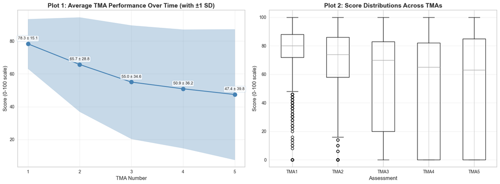

```python
### 4.1.1  Calculating and plotting average scores, SDs and boxplots over time

# Create working copy to preserve original data
data_explore = data_full.copy()

# Define assessment column groups
assessment_cols = ['CMA_average', 'TMA1', 'TMA2', 'TMA3', 'TMA4', 'TMA5']
tma_cols = ['TMA1', 'TMA2', 'TMA3', 'TMA4', 'TMA5']

# Normalize TMA scores to 0-100 scale based on their weights
# TMA1, TMA2: max 12.5 points (12.5% weight) → multiply by 8 to get 0-100
# TMA3, TMA4, TMA5: max 25 points (25% weight) → multiply by 4 to get 0-100
data_explore['TMA1_norm'] = data_explore['TMA1'] * 8
data_explore['TMA2_norm'] = data_explore['TMA2'] * 8
data_explore['TMA3_norm'] = data_explore['TMA3'] * 4
data_explore['TMA4_norm'] = data_explore['TMA4'] * 4
data_explore['TMA5_norm'] = data_explore['TMA5'] * 4

tma_cols_norm = ['TMA1_norm', 'TMA2_norm', 'TMA3_norm', 'TMA4_norm', 'TMA5_norm']

# Calculate descriptive statistics for normalized TMA progression
tma_means = data_explore[tma_cols_norm].mean()
tma_stds = data_explore[tma_cols_norm].std()

# Create figure with two subplots
fig, (ax1, ax2) = plt.subplots(1, 2, figsize=(16, 6))

# Plot 1: TMA progression over time with variance band
ax1.plot(range(1, 6), tma_means, marker='o', linewidth=2, markersize=10, color='steelblue')
ax1.fill_between(range(1, 6),
                  tma_means - tma_stds,
                  tma_means + tma_stds,
                  alpha=0.3, color='steelblue')

# Add labels for mean and SD at each point
for i in range(5):
    mean_val = tma_means.iloc[i]
    std_val = tma_stds.iloc[i]
    ax1.annotate(f'{mean_val:.1f} ± {std_val:.1f}',
                 xy=(i+1, mean_val),
                 xytext=(0, 10),  # Offset 10 points above
                 textcoords='offset points',
                 ha='center',
                 fontsize=9,
                 bbox=dict(boxstyle='round,pad=0.3', facecolor='white', edgecolor='steelblue', alpha=0.7))

ax1.set_xlabel('TMA Number', fontsize=12)
ax1.set_ylabel('Score (0-100 scale)', fontsize=12)
ax1.set_title('Plot 1: Average TMA Performance Over Time (with ±1 SD)', fontsize=14, fontweight='bold')
ax1.grid(alpha=0.3)
ax1.set_xticks(range(1, 6))

# Plot 2: Distribution comparison via boxplots
assessment_data_norm = data_explore[tma_cols_norm]
assessment_data_norm.columns = ['TMA1', 'TMA2', 'TMA3', 'TMA4', 'TMA5']  # Rename for cleaner labels
assessment_data_norm.boxplot(ax=ax2)
ax2.set_xlabel('Assessment', fontsize=12)
ax2.set_ylabel('Score (0-100 scale)', fontsize=12)
ax2.set_title('Plot 2: Score Distributions Across TMAs', fontsize=14, fontweight='bold')
ax2.grid(axis='y', alpha=0.3)

plt.tight_layout()
plt.show()
```

**Performance Trajectory (Plot 1):**

Average TMA scores (normalized to 0-100 scale) reveal a **consistent declining trend** across the module:

- **TMA1** (78.3 ± 15.1): Strongest performance with relatively low variance
- **TMA2** (65.7 ± 28.8): Sharp decline with nearly doubled standard deviation
- **TMA3** (55.0 ± 34.6): Continued decline, further variance increase
- **TMA4** (50.9 ± 36.2): Performance stabilizes at lower level
- **TMA5** (47.4 ± 39.8): Lowest average with maximum variance

Students lose **30.9 points** on average from TMA1 to TMA5, representing a 39% performance decline.

**Variance Evolution (Plot 1):**

Standard deviation **increases 2.6× from TMA1 to TMA5**, indicating:

- **Early uniformity**: Students begin with similar performance levels
- **Progressive differentiation**: Performance gap widens dramatically over time
- **Polarization**: By TMA5, student population splits between high achievers and struggling/withdrawn students

**Distribution Characteristics (Plot 2):**

The boxplots reveal:

- **TMA1-TMA2**: Relatively compact distributions with medians near 80, many zero-score outliers (non-submissions)
- **TMA3-TMA5**: Extremely wide distributions spanning full 0-100 range
- **Bimodal tendency**: Later TMAs show clustering at both high scores (60-100) and zeros (withdrawals)
- **Declining medians**: From ~80 (TMA1) to ~65 (TMA5), tracking the downward trend

Through the assessments many students drop in perfomance while others keep perfomance consistently. This pattern could be something that the clustering analysis picks up on especially if it correlates with observable patterns in other key metrics.

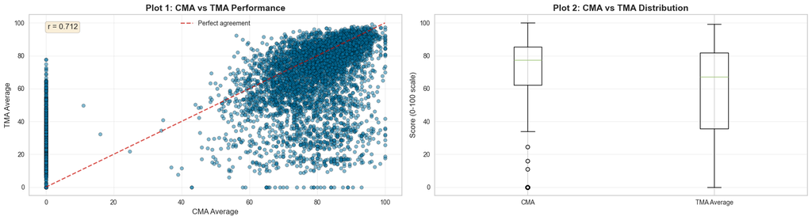

```
CMA vs TMA Analysis:
======================================================================
CMA Average: 63.31 ± 33.43
TMA Average: 59.48 ± 26.19
Correlation: 0.712
```

```python
### Comparing automated vs tutor-marked assessments
fig, axes = plt.subplots(1, 2, figsize=(18, 5))

# Calculate TMA average using normalized scores
tma_average = data_explore[tma_cols_norm].mean(axis=1)

# Plot 1: Direct comparison
axes[0].scatter(data_explore['CMA_average'], tma_average,
                alpha=0.5, s=30, edgecolors='black', linewidth=0.5)
axes[0].plot([0, 100], [0, 100], 'r--', alpha=0.7, label='Perfect agreement')
axes[0].set_xlabel('CMA Average', fontsize=12)
axes[0].set_ylabel('TMA Average', fontsize=12)
axes[0].set_title('Plot 1: CMA vs TMA Performance', fontsize=14, fontweight='bold')
axes[0].legend()
axes[0].grid(alpha=0.3)

# Calculate correlation and insert
cma_tma_corr = data_explore['CMA_average'].corr(tma_average)
axes[0].text(0.05, 0.95, f'r = {cma_tma_corr:.3f}',
             transform=axes[0].transAxes, fontsize=12,
             verticalalignment='top', bbox=dict(boxstyle='round', facecolor='wheat', alpha=0.5))

# Plot 2: Box plots side by side
axes[1].boxplot([data_explore['CMA_average'].dropna(), tma_average.dropna()],
                labels=['CMA', 'TMA Average'])
axes[1].set_ylabel('Score (0-100 scale)', fontsize=12)
axes[1].set_title('Plot 2: CMA vs TMA Distribution', fontsize=14, fontweight='bold')
axes[1].grid(axis='y', alpha=0.3)

plt.tight_layout()
plt.show()

print("\nCMA vs TMA Analysis:")
print("="*70)
print(f"CMA Average: {data_explore['CMA_average'].mean():.2f} ± {data_explore['CMA_average'].std():.2f}")
print(f"TMA Average: {tma_average.mean():.2f} ± {tma_average.std():.2f}")
print(f"Correlation: {cma_tma_corr:.3f}")
```

**Plot 1:** The scatter plot reveals a **strong positive correlation (r=0.712)** between computer-marked (CMA) and tutor-marked (TMA) assessments, indicating students who excel in one format tend to excel in the other. However, the relationship shows notable deviations:

- **Dense cluster around diagonal**: Majority of students perform consistently across both assessment types
- **Below-diagonal concentration**: Many students score higher on CMAs than TMAs
- **Zero-score artifacts**: Vertical (x=0) and horizontal (y=0) lines represent students who didn't complete one or both assessment types

The moderate correlation (not near 1.0) suggests assessment format does matter—some students' abilities are better captured by one format than the other.

### **Analysis 2: Engagement Patterns and Their Relationship to Performance**

To investigate how student engagement relates to academic outcomes, we create two composite metrics: (1) a **performance score** by normalizing all assessments to 0-100 scale and taking their average and (2)**efficiency** by dividing the perfomance score through the total number of clicks of a student. We then plot these metrics against each other, look at the distribution of efficiency and categorize students into different learning efficiency/outcome profiles to learn about the distributin of students across these profiles.

> **Note**: The total number of clicks is here used to proxy student engagement, possible future work could investigate this further by standardizing across multiple behavioural features and take their mean to compare against the perfmormance score.

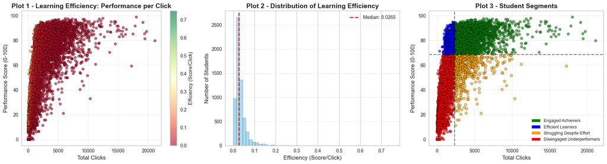

```
Student Segments:
======================================================================
High Eng + High Perf          : 2485 ( 40.0%)
High Eng + Low Perf           :  620 ( 10.0%)
Low Eng + Low Perf            : 2484 ( 40.0%)
Low Eng + High Perf           :  621 ( 10.0%)
```

```python
### Analysis 2: Learning Efficiency and Student Segmentation

# Normalize all assessments to 0-100 scale for fair comparison
# This creates a unified performance metric across differently-weighted assessments
assessment_normalized = data_explore[assessment_cols].copy()

# TMA1, TMA2 have max weighted values of 12.5 (12.5% of final grade)
assessment_normalized['TMA1'] = (data_explore['TMA1'] / 12.5) * 100
assessment_normalized['TMA2'] = (data_explore['TMA2'] / 12.5) * 100

# TMA3, TMA4, TMA5 have max weighted values of 25 (25% of final grade each)
assessment_normalized['TMA3'] = (data_explore['TMA3'] / 25.0) * 100
assessment_normalized['TMA4'] = (data_explore['TMA4'] / 25.0) * 100
assessment_normalized['TMA5'] = (data_explore['TMA5'] / 25.0) * 100

# CMA_average already on 0-100 scale, no transformation needed

# Calculate overall performance score as mean of all normalized assessments
data_explore['performance_score'] = assessment_normalized.mean(axis=1)

# Calculate learning efficiency: how much performance per unit of engagement
# Add 1 to denominator to avoid division by zero for students with no clicks
data_explore['efficiency'] = data_explore['performance_score'] / (data_explore['total_clicks'] + 1)

# Create three-panel visualization
fig, axes = plt.subplots(1, 3, figsize=(18, 5))

# === PLOT 1: Efficiency-Colored Scatter Plot ===
# Shows engagement vs performance with color indicating efficiency
# Green = high efficiency (good performance with fewer clicks)
# Red = low efficiency (many clicks but poor performance)
scatter = axes[0].scatter(data_explore['total_clicks'],
                          data_explore['performance_score'],
                          c=data_explore['efficiency'],
                          cmap='RdYlGn',  # Red-Yellow-Green colormap
                          alpha=0.6,
                          s=30,
                          edgecolors='black',
                          linewidth=0.5)
axes[0].set_xlabel('Total Clicks', fontsize=12)
axes[0].set_ylabel('Performance Score (0-100)', fontsize=12)
axes[0].set_title('Plot 1 - Learning Efficiency: Performance per Click', fontsize=14, fontweight='bold')
plt.colorbar(scatter, ax=axes[0], label='Efficiency (Score/Click)')
axes[0].grid(alpha=0.3)

# === PLOT 2: Efficiency Distribution ===
# Histogram showing how learning efficiency is distributed across students
# Helps identify if most students are efficient or if there's wide variation
axes[1].hist(data_explore['efficiency'], bins=50, edgecolor='black', alpha=0.7, color='skyblue')
axes[1].axvline(data_explore['efficiency'].median(), color='red', linestyle='--',
                linewidth=2, label=f'Median: {data_explore["efficiency"].median():.4f}')
axes[1].set_xlabel('Efficiency (Score/Click)', fontsize=12)
axes[1].set_ylabel('Number of Students', fontsize=12)
axes[1].set_title('Plot 2 - Distribution of Learning Efficiency', fontsize=14, fontweight='bold')
axes[1].legend()
axes[1].grid(axis='y', alpha=0.3)

# === PLOT 3: Four-Quadrant Student Segmentation ===
# Divide students into four groups based on median splits of engagement and performance

# Calculate median values as thresholds for segmentation
median_engagement = data_explore['total_clicks'].median()
median_performance = data_explore['performance_score'].median()

# Classify each student into one of four segments
colors = []
labels_list = []
for _, row in data_explore.iterrows():
    # Top-right quadrant: High engagement AND high performance
    if row['total_clicks'] >= median_engagement and row['performance_score'] >= median_performance:
        colors.append('green')
        labels_list.append('High Eng + High Perf')
    # Bottom-right quadrant: High engagement BUT low performance (concerning group)
    elif row['total_clicks'] >= median_engagement and row['performance_score'] < median_performance:
        colors.append('orange')
        labels_list.append('High Eng + Low Perf')
    # Top-left quadrant: Low engagement BUT high performance (efficient learners)
    elif row['total_clicks'] < median_engagement and row['performance_score'] >= median_performance:
        colors.append('blue')
        labels_list.append('Low Eng + High Perf')
    # Bottom-left quadrant: Low engagement AND low performance (at-risk)
    else:
        colors.append('red')
        labels_list.append('Low Eng + Low Perf')

# Create scatter plot with segment-based coloring
axes[2].scatter(data_explore['total_clicks'], data_explore['performance_score'],
                c=colors, alpha=0.6, s=30, edgecolors='black', linewidth=0.5)

# Draw median threshold lines to show quadrant boundaries
axes[2].axvline(median_engagement, color='black', linestyle='--', alpha=0.5)
axes[2].axhline(median_performance, color='black', linestyle='--', alpha=0.5)

axes[2].set_xlabel('Total Clicks', fontsize=12)
axes[2].set_ylabel('Performance Score (0-100)', fontsize=12)
axes[2].set_title('Plot 3 - Student Segments', fontsize=14, fontweight='bold')
axes[2].grid(alpha=0.3)

# Add interpretive legend for the four student segments
legend_elements = [
    Patch(facecolor='green', label='Engaged Achievers'),
    Patch(facecolor='blue', label='Efficient Learners'),
    Patch(facecolor='orange', label='Struggling Despite Effort'),
    Patch(facecolor='red', label='Disengaged Underperformers')
]
axes[2].legend(handles=legend_elements, loc='best', fontsize=9)

plt.tight_layout()
plt.show()

# Calculate and display segment statistics
segment_counts = Counter(labels_list)
print("\nStudent Segments:")
print("="*70)
for segment, count in segment_counts.items():
    print(f"{segment:30s}: {count:4d} ({count/len(data_explore)*100:5.1f}%)")
```

**Plot 1:** We see a moderate correlation between effort and perfomance. Students with high performance tend to have more clicks (more effort). Among the students with lower performance students with a high number of clicks become more rare. Students with high efficiency relative to the other students are very rare(jsut very few green points visible).

**Plot 2:** This efficiency trend shows in plot 2. The efficiency distribution is **highly right-skewed** with the vast majority of students clustered near zero efficiency (median: 0.0265). Almost all students fall within the 0.0-0.1 efficiency range, indicating most students require substantial platform engagement to achieve their performance levels. Very few students demonstrate high efficiency (>0.2), suggesting that achieving strong performance with minimal clicks is rare. The long tail extending to ~0.7 represents exceptional outliers who achieved relatively high scores with very few interactions.

**Plot 3:** The four-quadrant segmentation reveals a **polarized student population**. The two largest groups are **Engaged Achievers** (green, 40.0%) and **Disengaged Underperformers** (red, 40.0%), representing students whose engagement matches their outcomes. Notably, **Efficient Learners** (blue, 10.0%) achieve high performance despite below-median engagement, clustering in the upper-left quadrant—these students demonstrate effective learning strategies. The **Struggling Despite Effort** group (orange, 10.0%) is particularly concerning: they invest high engagement but achieve below-median performance, suggesting they may need targeted intervention or alternative learning support. The clear quadrant separation indicates engagement level is a strong predictor of performance, though the presence of efficient learners shows high engagement isn't strictly necessary for success.

**Insight Value:** From this superficial look (only total_clicks), the students effort seems to discriminate them to a degree in terms of how well they perform. Post-clustering, we can validate results by checking if discovered clusters align with these exploratory quadrants. Strong agreement would confirm clustering captured pedagogically meaningful patterns rather than arbitrary mathematical groupings.

### **4.3 Analysis: Time Management and Reactivity Patterns**

This analysis examines how students manage deadlines and distribute their learning activities over time. We focus on two key behavioral dimensions: **reactivity** (submission timing relative to deadlines) and **temporal consistency** (spread of engagement across the semester). These patterns reveal time management strategies that correlate with academic success and can identify students at risk due to procrastination or inconsistent study habits.

**Key Questions:**

- Do students who submit early perform better than last-minute submitters?
- Does spreading learning activity across more days improve outcomes?
- Can we identify distinct time management profiles (e.g., planners vs. procrastinators)?

#### Key Findings

**Submission Timing (Reactivity):**

- **Higher reactivity = Earlier submission** (more days before deadline)
- **Lower reactivity = Closer to deadline** (last-minute submission)
- Correlation analysis reveals relationship between submission timing and performance
- Negative reactivity values indicate unusual pre-start submissions

**Learning Consistency:**

- Unique active days measures spread of learning activity over time
- Positive correlation between consistency and performance
- Students active on more unique days tend to perform better

**Time Management Profiles Identified:**

1. **Proactive Planners**: Early submission + High consistency → Best performers
2. **Early Submitters**: Early submission + Lower consistency → Good performers
3. **Steady Workers**: Moderate timing + High consistency → Reliable performers
4. **Moderate Planners**: Moderate timing + Lower consistency → Average performers
5. **Last-Minute Consistent**: Close to deadline + High consistency → Mixed performance
6. **Procrastinators**: Close to deadline + Low consistency → Poorest performers
7. **Pre-Start Submitters**: Unusual early submissions (potential data anomalies)

#### Implications for Clustering

- Time management patterns provide behavioral dimension complementary to performance
- Early submitters and consistent learners form distinct, successful profiles
- Procrastination patterns strongly associated with poor outcomes
- These features should help clustering identify at-risk behavioral patterns

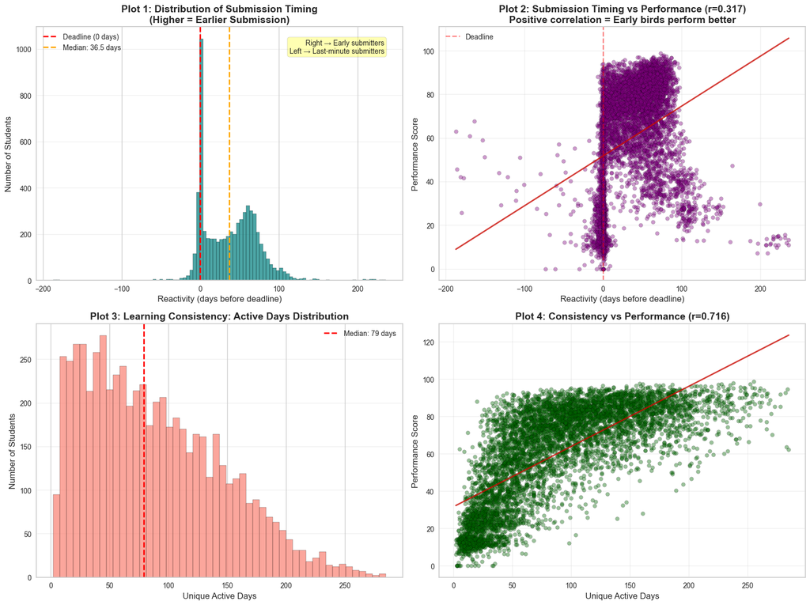

```python
fig, axes = plt.subplots(2, 2, figsize=(16, 12))

# Plot 1: Reactivity distribution
axes[0, 0].hist(data_explore['reactivity'], bins=100, edgecolor='black', alpha=0.7, color='teal')
axes[0, 0].axvline(0, color='red', linestyle='--', linewidth=2, label='Deadline (0 days)')
axes[0, 0].axvline(data_explore['reactivity'].median(), color='orange', linestyle='--',
                   linewidth=2, label=f'Median: {data_explore["reactivity"].median():.1f} days')
axes[0, 0].set_xlabel('Reactivity (days before deadline)', fontsize=12)
axes[0, 0].set_ylabel('Number of Students', fontsize=12)
axes[0, 0].set_title('Plot 1: Distribution of Submission Timing\n(Higher = Earlier Submission)', fontsize=14, fontweight='bold')
axes[0, 0].legend()
axes[0, 0].grid(axis='y', alpha=0.3)

# Add annotation
axes[0, 0].text(0.95, 0.95, 'Right → Early submitters\nLeft → Last-minute submitters',
                transform=axes[0, 0].transAxes, fontsize=10,
                verticalalignment='top', horizontalalignment='right',
                bbox=dict(boxstyle='round', facecolor='yellow', alpha=0.3))

# Plot 2: Reactivity vs Performance
axes[0, 1].scatter(data_explore['reactivity'], data_explore['performance_score'],
                   alpha=0.4, s=30, edgecolors='black', linewidth=0.3, color='purple')
axes[0, 1].axvline(0, color='red', linestyle='--', alpha=0.5, label='Deadline')

# Add trend line
z = np.polyfit(data_explore['reactivity'].dropna(),
               data_explore['performance_score'][data_explore['reactivity'].notna()], 1)
p = np.poly1d(z)
x_trend = np.linspace(data_explore['reactivity'].min(), data_explore['reactivity'].max(), 100)
axes[0, 1].plot(x_trend, p(x_trend), "r-", alpha=0.8, linewidth=2)

corr_react = data_explore['reactivity'].corr(data_explore['performance_score'])
axes[0, 1].set_xlabel('Reactivity (days before deadline)', fontsize=12)
axes[0, 1].set_ylabel('Performance Score', fontsize=12)
axes[0, 1].set_title(f'Plot 2: Submission Timing vs Performance (r={corr_react:.3f})\nPositive correlation = Early birds perform better',
                     fontsize=14, fontweight='bold')
axes[0, 1].legend()
axes[0, 1].grid(alpha=0.3)

# Plot 3: Active days distribution
axes[1, 0].hist(data_explore['unique_dates'], bins=50, edgecolor='black', alpha=0.7, color='salmon')
axes[1, 0].axvline(data_explore['unique_dates'].median(), color='red', linestyle='--',
                   linewidth=2, label=f'Median: {data_explore["unique_dates"].median():.0f} days')
axes[1, 0].set_xlabel('Unique Active Days', fontsize=12)
axes[1, 0].set_ylabel('Number of Students', fontsize=12)
axes[1, 0].set_title('Plot 3: Learning Consistency: Active Days Distribution', fontsize=14, fontweight='bold')
axes[1, 0].legend()
axes[1, 0].grid(axis='y', alpha=0.3)

# Plot 4: Consistency vs Performance
axes[1, 1].scatter(data_explore['unique_dates'], data_explore['performance_score'],
                   alpha=0.4, s=30, edgecolors='black', linewidth=0.3, color='darkgreen')

# Add trend line
z = np.polyfit(data_explore['unique_dates'].dropna(),
               data_explore['performance_score'][data_explore['unique_dates'].notna()], 1)
p = np.poly1d(z)
x_trend = np.linspace(data_explore['unique_dates'].min(), data_explore['unique_dates'].max(), 100)
axes[1, 1].plot(x_trend, p(x_trend), "r-", alpha=0.8, linewidth=2)

corr_dates = data_explore['unique_dates'].corr(data_explore['performance_score'])
axes[1, 1].set_xlabel('Unique Active Days', fontsize=12)
axes[1, 1].set_ylabel('Performance Score', fontsize=12)
axes[1, 1].set_title(f'Plot 4: Consistency vs Performance (r={corr_dates:.3f})', fontsize=14, fontweight='bold')
axes[1, 1].grid(alpha=0.3)

plt.tight_layout()
plt.show()
```

**Reactivity and Performance (Plot 2):**

A **weak-to-moderate positive correlation (r=0.317)** exists between submission timing and performance. While the trend line slopes upward (early birds perform better), the substantial scatter indicates early submission alone doesn't guarantee success. Many high performers cluster near the deadline (reactivity 0-50 days), while some very early submitters still achieve only moderate scores. This suggests submission timing is a factor but not the dominant predictor of performance.

**Consistency and Performance (Plot 4):**

Temporal consistency shows a **strong positive correlation (r=0.716)** with performance—students active on more unique days achieve substantially higher scores. This relationship is **more than twice as strong** as reactivity (0.716 vs 0.317), suggesting *consistent engagement over time* is far more predictive of success than early submission timing. The dense upward-trending cloud shows that nearly every additional active day corresponds to performance gains, with the relationship holding across the full performance spectrum.

**Critical Insight:** Time management matters, but **consistency dominates timing**. Students who spread learning across many days dramatically outperform those who submit early but engage sporadically. This has major implications for identifying at-risk students—low unique_dates is a stronger warning signal than late submission.

**Creating Time Management Profiles:**

To better understand student behavior patterns, we categorize students into seven profiles based on their submission timing (reactivity) and learning consistency (unique active days). These profiles combine both temporal dimensions to identify distinct time management strategies:

- **High reactivity** (>10 days early) vs **Moderate** (5-10 days) vs **Low** (<5 days)
- **High consistency** (above median active days) vs **Low consistency** (below median)

```
Time Management Profiles:
======================================================================
                          mean    std  count
time_management_profile
Proactive Planner        78.58  11.57   2771
Steady Worker            75.40  10.96     93
Last-Minute Consistent   69.44  15.79    130
Early Submitter          55.80  20.32   1456
Moderate Planner         55.50  26.06    123
Pre-Start Submitter      35.34  22.21    722
Procrastinator           28.36  20.89    915
```

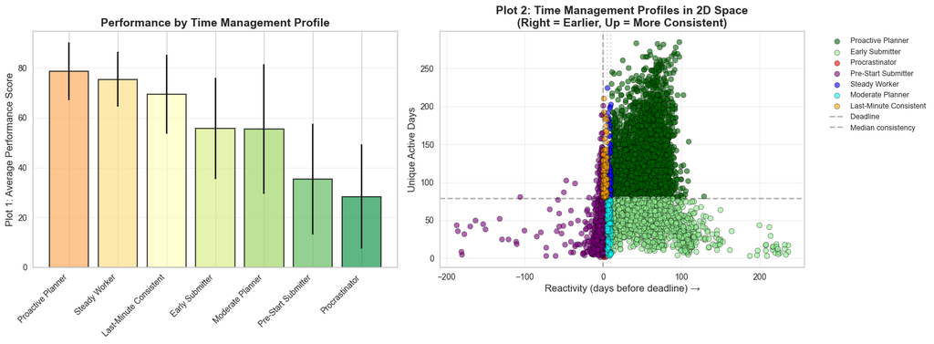

```python
# Create time management categories - CORRECTED VERSION
def categorize_time_management(row):
    reactivity = row['reactivity']
    consistency = row['unique_dates']
    median_consistency = data_explore['unique_dates'].median()

    # Higher reactivity = earlier submission
    # Lower reactivity = closer to deadline

    if reactivity > 10 and consistency > median_consistency:
        return 'Proactive Planner'  # Early + Consistent
    elif reactivity > 10 and consistency <= median_consistency:
        return 'Early Submitter'  # Early but less consistent engagement
    elif 5 <= reactivity <= 10 and consistency > median_consistency:
        return 'Steady Worker'  # Moderate advance + Consistent
    elif 5 <= reactivity <= 10 and consistency <= median_consistency:
        return 'Moderate Planner'  # Moderate advance, less consistent
    elif 0 <= reactivity < 5 and consistency > median_consistency:
        return 'Last-Minute Consistent'  # Close to deadline but active throughout
    elif 0 <= reactivity < 5 and consistency <= median_consistency:
        return 'Procrastinator'  # Close to deadline + inconsistent
    else:  # reactivity < 0
        return 'Pre-Start Submitter'  # Submitted before module even started (unusual)

data_explore['time_management_profile'] = data_explore.apply(categorize_time_management, axis=1)

# Analyze profiles
profile_performance = data_explore.groupby('time_management_profile')['performance_score'].agg(['mean', 'std', 'count'])
profile_performance = profile_performance.sort_values('mean', ascending=False)

print("\nTime Management Profiles:")
print("="*70)
print(profile_performance.round(2))

# Visualize profiles
fig, (ax1, ax2) = plt.subplots(1, 2, figsize=(16, 6))

# Bar plot of profile performance
colors_profile = plt.cm.RdYlGn(np.linspace(0.3, 0.9, len(profile_performance)))
ax1.bar(range(len(profile_performance)), profile_performance['mean'],
        yerr=profile_performance['std'], capsize=5, alpha=0.7, color=colors_profile,
        edgecolor='black', linewidth=1.5)
ax1.set_xticks(range(len(profile_performance)))
ax1.set_xticklabels(profile_performance.index, rotation=45, ha='right')
ax1.set_ylabel('Plot 1: Average Performance Score', fontsize=12)
ax1.set_title('Performance by Time Management Profile', fontsize=14, fontweight='bold')
ax1.grid(axis='y', alpha=0.3)

# Scatter with profile coloring
profile_colors = {
    'Proactive Planner': 'darkgreen',
    'Early Submitter': 'lightgreen',
    'Steady Worker': 'blue',
    'Moderate Planner': 'cyan',
    'Last-Minute Consistent': 'orange',
    'Procrastinator': 'red',
    'Pre-Start Submitter': 'purple'
}

for profile in data_explore['time_management_profile'].unique():
    if profile in profile_colors:
        mask = data_explore['time_management_profile'] == profile
        ax2.scatter(data_explore.loc[mask, 'reactivity'],
                   data_explore.loc[mask, 'unique_dates'],
                   c=profile_colors[profile], label=profile, alpha=0.6, s=40,
                   edgecolors='black', linewidth=0.5)

ax2.axvline(0, color='black', linestyle='--', alpha=0.3, label='Deadline')
ax2.axvline(5, color='gray', linestyle=':', alpha=0.3)
ax2.axvline(10, color='gray', linestyle=':', alpha=0.3)
ax2.axhline(data_explore['unique_dates'].median(), color='black', linestyle='--', alpha=0.3, label='Median consistency')
ax2.set_xlabel('Reactivity (days before deadline) →', fontsize=12)
ax2.set_ylabel('Unique Active Days', fontsize=12)
ax2.set_title('Plot 2: Time Management Profiles in 2D Space\n(Right = Earlier, Up = More Consistent)', fontsize=14, fontweight='bold')
ax2.legend(bbox_to_anchor=(1.05, 1), loc='upper left', fontsize=9)
ax2.grid(alpha=0.3)

plt.tight_layout()
plt.show()
```

**Time Management Profile Performance (Plot 1):**

**Spatial Distribution (Plot 2):**

**Clustering Implications:**

These patterns strongly suggest our clustering algorithms should:

- **Prioritize unique_dates** (consistency) over reactivity in feature importance
- Successfully distinguish the three high-performing groups (Proactive Planners, Steady Workers, Last-Minute Consistent) from struggling students
- Identify the "Procrastinator" profile as a distinct at-risk cluster
- Possibly group Early Submitters with Moderate Planners (similar performance despite different timing)

If clustering fails to separate consistent learners from inconsistent ones regardless of submission timing, the algorithms are missing the most important behavioral dimension revealed by this analysis.

### **4.4 EDA Conclusion**

**Key Insights for Clustering:**

1. **Multi-dimensional student profiles** exist across performance, engagement, and time management dimensions
2. **Consistency predicts success**: Temporal patterns (unique active dates) correlate more strongly with performance than engagement volume
3. **Not all engagement is beneficial**: Efficiency matters—some students achieve high performance with minimal clicks
4. **Assessment performance declines over time**: Students start strong but show progressive differentiation by later TMAs
5. **Clear at-risk indicators**: Low engagement + Late submission + Declining performance + Low consistency

**Expected Cluster Characteristics:**

Based on these exploratory analyses, we anticipate clusters representing:

- **High achievers**: Early submission, high consistency, strong performance across all assessments
- **Efficient learners**: Low engagement volume but high performance, moderate consistency
- **Struggling students**: High effort (clicks) but low performance, inconsistent patterns
- **At-risk/Disengaged**: Low engagement, late submissions, poor performance, sporadic activity
- **Average/Steady**: Moderate across all dimensions, following typical performance trajectory

These statistically-identified patterns provide validation criteria for clustering results. Strong alignment between discovered clusters and these exploratory segments would confirm that unsupervised methods successfully captured pedagogically meaningful student profiles rather than arbitrary mathematical groupings.

## **5. Dimensionality Reduction via Principal Component Analysis**

Principal Component Analysis (PCA) transforms our 15 correlated features into uncorrelated principal components, reducing dimensionality while preserving maximum variance. This transformation serves multiple purposes: it removes multicollinearity between features (e.g., `total_clicks` and `activity_clicks` with r=0.89), reduces computational complexity for clustering algorithms, and potentially improves clustering quality by focusing on the most important variance directions.

**Why PCA for this dataset?**

1. Standardize features and analyze correlation visually
2. Compute principal components and analyze variance explained (visually), then decide for optimal number of components balancing information preservation and dimensionality reduction
3. Analye Loadings for top components
4. Create `data_pca` dataset with respective number of components for clustering experiments
5. Plot 2 most important components against eachother to see if rough patterns emerge

> **Note:** Unlike Task 6 (feature selection), PCA creates new features through linear combinations. Original features are no longer directly interpretable, but the transformed space captures the same underlying variance structure.

### **5.1 Standardize features and analyze correlation visually**

```python
### Standardize the features, to make it compatible with PCA
scaler = StandardScaler()
data_scaled = scaler.fit_transform(data_full)
data_scaled_df = pd.DataFrame(data_scaled, index=data_full.index, columns=data_full.columns)

# Confirm Transformation
print(f"Shape: {data_scaled_df.shape}")
data_scaled_df.head()
```

```
Shape: (6210, 15)
```

| stu_present_id | reactivity | CMA_average | TMA1 | TMA2 | TMA3 | TMA4 | TMA5 | resource_count | unique_activity_count | total_clicks | activity_clicks | unique_dates | unique_activity_dates | avg_daily_clicks | avg_daily_activity_clicks |
| --- | --- | --- | --- | --- | --- | --- | --- | --- | --- | --- | --- | --- | --- | --- | --- |
| 100064201323 | -0.371683 | 0.721362 | 0.904495 | 0.912695 | 1.126900 | 1.163325 | 1.043608 | 1.095060 | 1.213820 | 1.588476 | 0.348753 | 1.844088 | 1.395326 | 0.255289 | -0.669688 |
| 1006742201412 | 1.614380 | 0.469247 | -0.021188 | -2.283898 | -1.589027 | -1.406727 | -1.190486 | 1.760527 | 0.253649 | -0.168897 | -0.411879 | -0.609258 | -0.237662 | 1.281262 | -0.434163 |
| 100788201323 | 0.534847 | 0.858102 | 0.904495 | 0.843204 | 0.982436 | 0.279006 | 0.993403 | -0.413333 | 0.733735 | 0.137237 | -0.202157 | 0.928402 | 0.306667 | -0.692160 | -0.621780 |
| 101217201321 | -0.959890 | -1.893792 | -4.252886 | -2.283898 | -1.589027 | -1.406727 | -1.190486 | -0.058417 | -1.186608 | -1.065831 | -0.985743 | -1.110293 | -0.963435 | -1.380684 | -1.048455 |
| 101217201422 | -1.264373 | -1.893792 | -0.682391 | -2.283898 | -1.589027 | -1.406727 | -1.190486 | 0.873238 | -0.226437 | -1.043075 | -0.955485 | -0.902968 | -0.623229 | -1.643059 | -1.317282 |

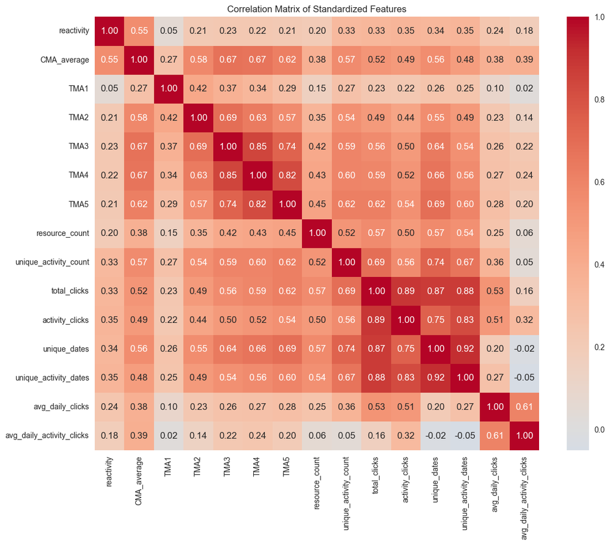

```python
### Analyze correlation structure on scaled data to verify PCA will make sense
# we have already looked at correlation
correlation_matrix = data_scaled_df.corr()

plt.figure(figsize=(12, 10))
sns.heatmap(correlation_matrix, annot=True, fmt='.2f', cmap='coolwarm', center=0)
plt.title('Correlation Matrix of Standardized Features')
plt.tight_layout()
plt.show()
```

The heatmap confirms significant correlation clusters justifying PCA application:

**Weaker Correlations:**

These correlation patterns indicate substantial redundancy—multiple features capture similar underlying constructs (general engagement, temporal consistency, assessment performance). PCA will consolidate this redundancy into fewer, orthogonal components.

### 5.2 **Compute principal components, analyze variance explained and decide for optimal number of components**

```python
### Fit PCA with all components to analyze variance explained
pca_full = PCA()
pca_transformed_full = pca_full.fit_transform(data_scaled)

# Create DataFrame with all components
df_pca_full = pd.DataFrame(
    pca_transformed_full,
    index=data_full.index,
    columns=[f'PC{i+1}' for i in range(pca_transformed_full.shape[1])]
)

print(f"Original dimensions: {data_scaled.shape[1]}")
print(f"PCA components created: {df_pca_full.shape[1]}")
```

```
Original dimensions: 15
PCA components created: 15
```

```python
### Calculate explained variance
explained_variance = pca_full.explained_variance_ratio_
cumulative_variance = np.cumsum(explained_variance)

print("Explained variance by component:")
for i, (var, cum_var) in enumerate(zip(explained_variance, cumulative_variance)):
    print(f"PC{i+1}: {var:.4f} (cumulative: {cum_var:.4f})")
```

```
Explained variance by component:
PC1: 0.5100 (cumulative: 0.5100)
PC2: 0.1099 (cumulative: 0.6199)
PC3: 0.0930 (cumulative: 0.7129)
PC4: 0.0639 (cumulative: 0.7767)
PC5: 0.0538 (cumulative: 0.8305)
PC6: 0.0403 (cumulative: 0.8708)
PC7: 0.0311 (cumulative: 0.9019)
PC8: 0.0279 (cumulative: 0.9298)
PC9: 0.0178 (cumulative: 0.9477)
PC10: 0.0153 (cumulative: 0.9630)
PC11: 0.0142 (cumulative: 0.9772)
PC12: 0.0085 (cumulative: 0.9857)
PC13: 0.0077 (cumulative: 0.9934)
PC14: 0.0052 (cumulative: 0.9986)
PC15: 0.0014 (cumulative: 1.0000)
```

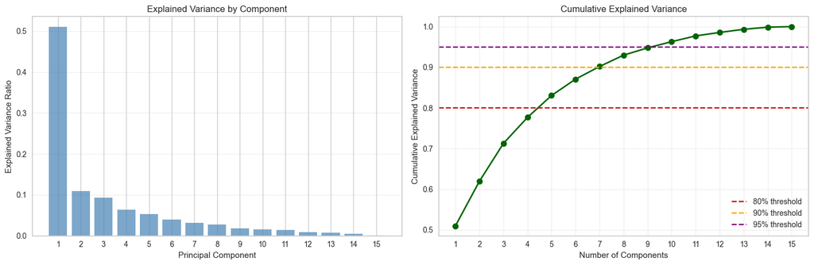

```python
### Visualize explained variance
fig, (ax1, ax2) = plt.subplots(1, 2, figsize=(15, 5))

# Individual explained variance
ax1.bar(range(1, len(explained_variance) + 1), explained_variance, alpha=0.7, color='steelblue')
ax1.set_xlabel('Principal Component')
ax1.set_ylabel('Explained Variance Ratio')
ax1.set_title('Explained Variance by Component')
ax1.set_xticks(range(1, len(explained_variance) + 1))
ax1.grid(axis='y', alpha=0.3)

# Cumulative explained variance
ax2.plot(range(1, len(cumulative_variance) + 1), cumulative_variance,
         marker='o', linestyle='-', color='darkgreen', linewidth=2, markersize=8)
ax2.axhline(y=0.80, color='r', linestyle='--', label='80% threshold')
ax2.axhline(y=0.90, color='orange', linestyle='--', label='90% threshold')
ax2.axhline(y=0.95, color='purple', linestyle='--', label='95% threshold')
ax2.set_xlabel('Number of Components')
ax2.set_ylabel('Cumulative Explained Variance')
ax2.set_title('Cumulative Explained Variance')
ax2.set_xticks(range(1, len(cumulative_variance) + 1))
ax2.legend()
ax2.grid(alpha=0.3)

plt.tight_layout()
plt.show()
```

The scree plot shows **PC1 dominates with ~51% of total variance**, followed by a gradual decline across subsequent components. Unlike datasets with a sharp "elbow," this pattern suggests behavioral variance is distributed across multiple dimensions without extreme concentration.

**Individual Component Contributions:**

**Cumulative Variance Thresholds:**

- **80% variance**: 5 components
- **90% variance**: 7 components
- **95% variance**: 10 components

**Decision: 6 Components (almost 90% Variance)**

We select **6 components** as the optimal balance:

**Substantial dimensionality reduction**: 15 → 6 features **Strong information preservation**: Retains roughly 90% of original variance

### 5.3 **Analye Loadings for top components**

```
Feature loadings for first 5 components:
                             PC1    PC2    PC3    PC4    PC5
reactivity                 0.154  0.206 -0.174  0.792  0.255
CMA_average                0.276  0.206  0.198  0.379 -0.037
TMA1                       0.137 -0.119  0.397 -0.205  0.799
TMA2                       0.257 -0.064  0.333  0.006  0.112
TMA3                       0.292 -0.031  0.349 -0.003 -0.190
TMA4                       0.298 -0.026  0.312 -0.026 -0.273
TMA5                       0.294 -0.048  0.203 -0.053 -0.304
resource_count             0.226 -0.109 -0.199 -0.113 -0.149
unique_activity_count      0.289 -0.107 -0.060  0.046 -0.014
total_clicks               0.318 -0.022 -0.310 -0.161  0.079
activity_clicks            0.294  0.090 -0.319 -0.174  0.132
unique_dates               0.319 -0.243 -0.178  0.028 -0.034
unique_activity_dates      0.304 -0.219 -0.298 -0.022  0.095
avg_daily_clicks           0.170  0.538 -0.171 -0.295  0.130
avg_daily_activity_clicks  0.093  0.682  0.101 -0.151 -0.082
```

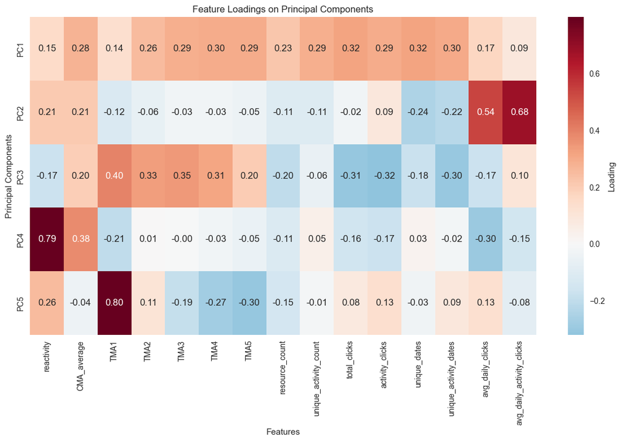

```python
### Examine loadings for top components to understand what they represent
n_components_to_analyze = 5

loadings = pd.DataFrame(
    pca_full.components_[:n_components_to_analyze].T,
    columns=[f'PC{i+1}' for i in range(n_components_to_analyze)],
    index=data_full.columns
)

print("Feature loadings for first 5 components:")
print(loadings.round(3))

# Visualize loadings
plt.figure(figsize=(12, 8))
sns.heatmap(loadings.T, annot=True, fmt='.2f', cmap='RdBu_r', center=0,
            cbar_kws={'label': 'Loading'})
plt.title('Feature Loadings on Principal Components')
plt.xlabel('Features')
plt.ylabel('Principal Components')
plt.tight_layout()
plt.show()
```

The loading heatmap reveals what each component captures. For the four most important components the loadings are structured the following way:

**PC3 - Assessment Performance Focus** (~9% variance):

- **Strong positive loadings**: `TMA1` (0.40), `TMA2` (0.33), `TMA3` (0.35), `TMA4` (0.31)
- **Negative loadings**: `reactivity` (-0.17), `total_clicks` (-0.31), `activity_clicks` (-0.32), `unique_dates` (-0.18), `unique_activity_dates` (-0.30)
- **Interpretation**: Pure academic performance independent of engagement volume, this maybe captures efficient learners who score well without excessive platform activity.

**PC4 - Submission Timing/Reactivity** (~6% variance):

- **Dominant loading**: `reactivity` (0.79)
- **Moderate positive**: `CMA_average` (0.38)
- **Negative**: `avg_daily_clicks` (-0.30)
- **Interpretation**: Early vs. late submission behavior, largely independent of other dimensions. Captures time management style.

**Clustering Implications:**

- **PC1** will drive primary cluster separation (engaged achievers vs. disengaged underperformers)
- **PC2** distinguishes cramming patterns from steady workers
- **PC3** identifies efficient learners (high performance, low effort)
- **PC4** separates proactive planners from procrastinators

### 5.4 **Create `data_pca` dataset for clustering experiments**

```python
# Apply PCA with 6 components
pca = PCA(n_components=6)
data_pca_array = pca.fit_transform(data_scaled)

# Create DataFrame for the PCA-transformed data
data_pca = pd.DataFrame(
    data_pca_array,
    index=data_full.index,
    columns=[f'PC{i+1}' for i in range(6)]
)

print("PCA transformation complete!")
print(f"Shape of data_pca: {data_pca.shape}")
data_pca.head()
```

```
PCA transformation complete!
Shape of data_pca: (6210, 6)
```

| stu_present_id | PC1 | PC2 | PC3 | PC4 | PC5 | PC6 |
| --- | --- | --- | --- | --- | --- | --- |
| 100064201323 | 3.683312 | -1.535057 | 0.086656 | -0.625168 | 0.003252 | 0.187658 |
| 1006742201412 | -1.237822 | 1.060675 | -2.458633 | 1.137857 | 1.036925 | 2.415648 |
| 100788201323 | 1.639307 | -1.102837 | 1.207006 | 0.918431 | 0.350875 | -0.430898 |
| 101217201321 | -5.039592 | -0.702099 | -2.546343 | 0.333892 | -3.117616 | 0.031845 |
| 101217201422 | -3.993259 | -1.840565 | -1.458476 | -0.594091 | -0.476338 | 1.320546 |

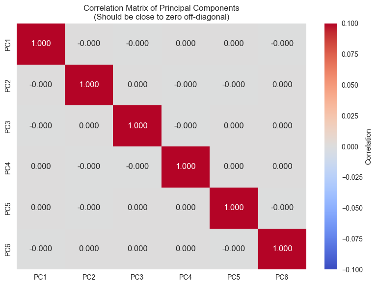

```
Maximum off-diagonal correlation: 2.8130888372730243e-16
```

```python
# Verify that principal components are uncorrelated
pca_correlation = data_pca.corr()

plt.figure(figsize=(8, 6))
sns.heatmap(pca_correlation, annot=True, fmt='.3f', cmap='coolwarm', center=0,
            vmin=-0.1, vmax=0.1, cbar_kws={'label': 'Correlation'})
plt.title('Correlation Matrix of Principal Components\n(Should be close to zero off-diagonal)')
plt.tight_layout()
plt.show()

print("Maximum off-diagonal correlation:",
      np.abs(pca_correlation.values[np.triu_indices_from(pca_correlation.values, k=1)]).max())
```

This mathematical orthogonality eliminates the multicollinearity issues present in the original feature space (e.g., total_clicks ↔ activity_clicks r=0.89). Distance-based clustering algorithms can now treat each dimension as truly independent, improving cluster quality and interpretability.

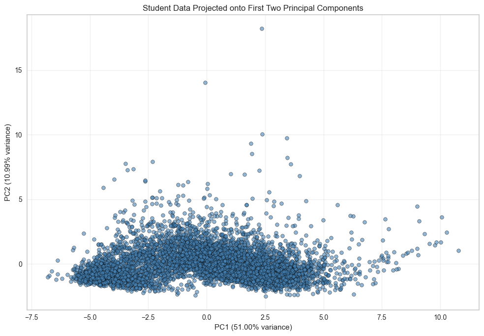

```python
# Visualize the data in the first 2 principal components
plt.figure(figsize=(10, 7))
scatter = plt.scatter(data_pca['PC1'], data_pca['PC2'],
                     alpha=0.6, s=30, c='steelblue', edgecolors='black', linewidth=0.5)
plt.xlabel(f'PC1 ({explained_variance[0]:.2%} variance)')
plt.ylabel(f'PC2 ({explained_variance[1]:.2%} variance)')
plt.title('Student Data Projected onto First Two Principal Components')
plt.grid(alpha=0.3)
plt.tight_layout()
plt.show()
```

The projection onto the first two principal components (PC1 vs PC2, explaining 62% of total variance) reveals the data structure:

**Distribution Pattern:**

- **Dense central cluster**: Majority of students concentrate in the region PC1 ∈ [-2.5, 2.5], PC2 ∈ [-2, 2]
- **Elongated horizontal spread**: Greater variance along PC1 (engagement) than PC2 (intensity pattern)
- **Right tail (PC1 > 5)**: Small group of extremely high-engagement students
- **Vertical spread**: Students distributed across PC2 (cramming vs. steady) at all PC1 levels
- **Outliers**: Scattered extreme points, particularly at PC1 > 7 (exceptionally high engagement)

**No Discrete Cluster Boundaries:**

The visualization shows a **continuous cloud rather than separated islands**. This doesn't mean clustering will fail—instead, it indicates:

- Student profiles exist along **continuums** rather than discrete categories
- Clustering algorithms will identify **density regions** and **natural boundaries** across all 6 dimensions
- The 2D projection (62% variance) cannot show separation occurring in PC3-PC6 dimensions
- Smooth transitions between behavioral patterns are expected (students don't fit into rigid boxes)

Algorithms will discover clusters based on the full 6-dimensional space, not just this 2D view. The elongated shape suggests PC1 (overall engagement) will be a primary separator, while PC2-PC6 will distinguish subtypes within engagement levels (e.g., high-engagement crampers vs. steady workers, efficient vs. struggling performers).

## **6. Dimensionality Reduction via Variance Threshold Feature Selection**

Unlike PCA (Task 5) which transforms features into new components, variance threshold feature selection directly removes low-variance features from the original dataset. This approach maintains interpretability, while eliminating features that contribute minimal discriminatory information.

1. Scale data with MinMaxScaler to [0, 1] range
2. Calculate/Visualize variance for each feature on scaled data, decide for threshold
3. Create `data_vt` dataset with VarianceThreshhold based on decision, Re-scale with StandardScaler

> **Note:** We use MinMaxScaler only for variance comparison and feature selection decisions, then apply StandardScaler to the retained features for actual clustering (maintaining consistency with `data_full` and `data_pca`).

### **6.1 Scaling Data with MinMaxScaler**

The range differences for the values of the different features are immense. To have comparable variances we scale the features. StandardScaler is nota fitting method for this tasks because it evens the SD between the features. MinMaxScaler is therefore used at this stage and the data will be rescaled later on with a standard scaler so that format is alligned with `data_pca`.

```python
### Scaling Data MinMaxScaler for VarianceThreshold
print("Applying MinMaxScaler for variance-based feature selection...")
scaler_minmax = MinMaxScaler()
data_minmax_array = scaler_minmax.fit_transform(data_full)

# Create new Dataframe with MinMaxScaler Data
data_minmax = pd.DataFrame(
    data_minmax_array,
    index=data_full.index,
    columns=data_full.columns
)

# Confirming the successful Transformation
print(f"\nValue ranges after MinMaxScaler:")
print(f"Min: {data_minmax.min().min():.6f}")
print(f"Max: {data_minmax.max().max():.6f}")
data_minmax
```

```
Applying MinMaxScaler for variance-based feature selection...

Value ranges after MinMaxScaler:
Min: 0.000000
Max: 1.000000
```

| stu_present_id | reactivity | CMA_average | TMA1 | TMA2 | TMA3 | TMA4 | TMA5 | resource_count | unique_activity_count | total_clicks | activity_clicks | unique_dates | unique_activity_dates | avg_daily_clicks | avg_daily_activity_clicks |
| --- | --- | --- | --- | --- | --- | --- | --- | --- | --- | --- | --- | --- | --- | --- | --- |
| 100064201323 | 0.497045 | 0.874286 | 0.92 | 0.92 | 0.94 | 0.93 | 0.89 | 0.133838 | 0.916667 | 0.308155 | 0.114502 | 0.681979 | 0.425455 | 0.137369 | 0.062602 |
| 1006742201412 | 0.666667 | 0.790000 | 0.78 | 0.00 | 0.00 | 0.00 | 0.00 | 0.171717 | 0.750000 | 0.114321 | 0.053883 | 0.180212 | 0.163636 | 0.193749 | 0.076596 |
| 100788201323 | 0.574468 | 0.920000 | 0.92 | 0.90 | 0.89 | 0.61 | 0.87 | 0.047980 | 0.833333 | 0.148087 | 0.070597 | 0.494700 | 0.250909 | 0.085303 | 0.065449 |
| 101217201321 | 0.446809 | 0.000000 | 0.14 | 0.00 | 0.00 | 0.00 | 0.00 | 0.068182 | 0.500000 | 0.015391 | 0.008149 | 0.077739 | 0.047273 | 0.047466 | 0.040098 |
| 101217201422 | 0.420804 | 0.000000 | 0.68 | 0.00 | 0.00 | 0.00 | 0.00 | 0.121212 | 0.666667 | 0.017901 | 0.010560 | 0.120141 | 0.101818 | 0.033048 | 0.024126 |
| ... | ... | ... | ... | ... | ... | ... | ... | ... | ... | ... | ... | ... | ... | ... | ... |
| 988019201322 | 0.533491 | 0.742000 | 0.90 | 0.96 | 0.15 | 0.56 | 0.00 | 0.060606 | 0.833333 | 0.096467 | 0.065358 | 0.455830 | 0.254545 | 0.055595 | 0.059726 |
| 990155201324 | 0.590229 | 0.905714 | 0.78 | 0.80 | 0.96 | 0.89 | 0.93 | 0.111111 | 0.916667 | 0.159737 | 0.092466 | 0.342756 | 0.221818 | 0.140751 | 0.096965 |
| 99670201412 | 0.614657 | 0.943333 | 0.94 | 0.92 | 0.88 | 0.92 | 0.85 | 0.068182 | 0.750000 | 0.099545 | 0.101281 | 0.240283 | 0.185455 | 0.122318 | 0.127034 |
| 999174201313 | 0.592593 | 0.885714 | 0.72 | 0.96 | 0.79 | 0.70 | 0.89 | 0.351010 | 0.916667 | 0.298352 | 0.144104 | 0.759717 | 0.600000 | 0.117430 | 0.055867 |
| 99993201313 | 0.547819 | 0.688333 | 0.90 | 0.96 | 0.67 | 0.89 | 0.83 | 0.088384 | 0.833333 | 0.185404 | 0.132712 | 0.508834 | 0.429091 | 0.107317 | 0.071944 |

6210 rows × 15 columns

### **6.2 Calculate/Visualize variance for each feature on scaled data**

```python
### Analyzing the Variance
feature_variances = data_minmax.var().sort_values()

print("Feature Variances after MinMaxScaler (sorted):")
print("="*60)
for feature, variance in feature_variances.items():
    print(f"{feature:30s}: {variance:.6f}")
```

```
Feature Variances after MinMaxScaler (sorted):
============================================================
avg_daily_clicks              : 0.003020
resource_count                : 0.003240
avg_daily_activity_clicks     : 0.003531
activity_clicks               : 0.006352
reactivity                    : 0.007295
total_clicks                  : 0.012168
TMA1                          : 0.022877
unique_activity_dates         : 0.025710
unique_activity_count         : 0.030135
unique_dates                  : 0.041837
TMA2                          : 0.082846
CMA_average                   : 0.111785
TMA3                          : 0.119809
TMA4                          : 0.130964
TMA5                          : 0.158726
```

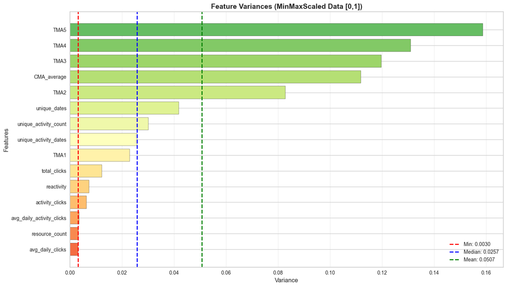

```python
### Visualizing feature variances

plt.figure(figsize=(14, 8))

# Horizontal bar chart of variances
colors = plt.cm.RdYlGn(np.linspace(0.2, 0.8, len(feature_variances)))
plt.barh(range(len(feature_variances)), feature_variances.values, color=colors, edgecolor='black')
plt.yticks(range(len(feature_variances)), feature_variances.index, fontsize=10)
plt.xlabel('Variance', fontsize=12)
plt.ylabel('Features', fontsize=12)
plt.title('Feature Variances (MinMaxScaled Data [0,1])', fontsize=14, fontweight='bold')
plt.grid(axis='x', alpha=0.3)

# Add reference lines
min_var = feature_variances.min()
median_var = feature_variances.median()
mean_var = feature_variances.mean()

plt.axvline(min_var, color='red', linestyle='--', linewidth=2,
            label=f'Min: {min_var:.4f}')
plt.axvline(median_var, color='blue', linestyle='--', linewidth=2,
            label=f'Median: {median_var:.4f}')
plt.axvline(mean_var, color='green', linestyle='--', linewidth=2,
            label=f'Mean: {mean_var:.4f}')

plt.legend(fontsize=10)
plt.tight_layout()
plt.show()
```

Variances range from **0.003020** to **0.158726**, showing substantial spread. The orders of magnitude difference between minimum and maximum variance indicates substantial disparity in feature discriminatory power. We observe a natural clustering of 5 features below 0.01 variance, suggesting these contribute minimal information on the normalized scale. As we saw in our EDA that `total_clicks` has a determining factor about our students learning outcomes (perfomance score), we should decide to **keep this feature in the dataset and remove everthing with lower variance**.

### **3. Create `data_vt` dataset with VarianceThreshhold based on threshold decision, Re-scale with StandardScaler**

```python
### Applying VarianceThreshold with manual threshold

# Get the variance of total_clicks as our threshold reference
threshold_variance = feature_variances['total_clicks']

# To keep total_clicks the threshold must be slightly lower.
threshold = threshold_variance * 0.98

# Apply VarianceThreshold
selector = VarianceThreshold(threshold=threshold)
data_vt_array = selector.fit_transform(data_minmax)

# Identify which features were selected
selected_features_mask = selector.get_support()
selected_features = data_minmax.columns[selected_features_mask].tolist()
removed_features = data_minmax.columns[~selected_features_mask].tolist()

print("\n" + "="*70)
print("VARIANCE THRESHOLD FEATURE SELECTION RESULTS")
print("="*70)
print(f"Threshold used:           {threshold:.10f}")
print(f"Reference (total_clicks): {threshold_variance:.10f}")
print(f"Strategy: Keep features with variance >= {threshold:.6f}")
print(f"\nOriginal features:        {data_minmax.shape[1]}")
print(f"Features after selection: {len(selected_features)}")
print(f"Features removed:         {len(removed_features)}")

# Verify total_clicks is retained
if 'total_clicks' in selected_features:
    print(f"\n✓ total_clicks successfully retained (variance: {feature_variances['total_clicks']:.6f})")
else:
    print(f"\n✗ WARNING: total_clicks was removed! Adjust threshold.")

print(f"\nRemoved feature(s):")
for feat in removed_features:
    print(f"  - {feat:30s} (variance: {feature_variances[feat]:.6f})")


# Re-scale selected features with StandardScaler for clustering (from data_full)
scaler_standard = StandardScaler()
data_vt_array_scaled = scaler_standard.fit_transform(data_full[selected_features])

data_vt = pd.DataFrame(
    data_vt_array_scaled,
    index=data_full.index,
    columns=selected_features
)

# Preview
print("\n rescaled data_vt preview:")
data_vt
```

```
======================================================================
VARIANCE THRESHOLD FEATURE SELECTION RESULTS
======================================================================
Threshold used:           0.0119241781
Reference (total_clicks): 0.0121675287
Strategy: Keep features with variance >= 0.011924

Original features:        15
Features after selection: 10
Features removed:         5

✓ total_clicks successfully retained (variance: 0.012168)

Removed feature(s):
  - reactivity                     (variance: 0.007295)
  - resource_count                 (variance: 0.003240)
  - activity_clicks                (variance: 0.006352)
  - avg_daily_clicks               (variance: 0.003020)
  - avg_daily_activity_clicks      (variance: 0.003531)

 rescaled data_vt preview:
```

| stu_present_id | CMA_average | TMA1 | TMA2 | TMA3 | TMA4 | TMA5 | unique_activity_count | total_clicks | unique_dates | unique_activity_dates |
| --- | --- | --- | --- | --- | --- | --- | --- | --- | --- | --- |
| 100064201323 | 0.721362 | 0.904495 | 0.912695 | 1.126900 | 1.163325 | 1.043608 | 1.213820 | 1.588476 | 1.844088 | 1.395326 |
| 1006742201412 | 0.469247 | -0.021188 | -2.283898 | -1.589027 | -1.406727 | -1.190486 | 0.253649 | -0.168897 | -0.609258 | -0.237662 |
| 100788201323 | 0.858102 | 0.904495 | 0.843204 | 0.982436 | 0.279006 | 0.993403 | 0.733735 | 0.137237 | 0.928402 | 0.306667 |
| 101217201321 | -1.893792 | -4.252886 | -2.283898 | -1.589027 | -1.406727 | -1.190486 | -1.186608 | -1.065831 | -1.110293 | -0.963435 |
| 101217201422 | -1.893792 | -0.682391 | -2.283898 | -1.589027 | -1.406727 | -1.190486 | -0.226437 | -1.043075 | -0.902968 | -0.623229 |
| ... | ... | ... | ... | ... | ... | ... | ... | ... | ... | ... |
| 988019201322 | 0.325670 | 0.772255 | 1.051678 | -1.155635 | 0.140832 | -1.190486 | 0.733735 | -0.330766 | 0.738355 | 0.329348 |
| 990155201324 | 0.815371 | -0.021188 | 0.495748 | 1.184686 | 1.052785 | 1.144016 | 1.213820 | 0.242860 | 0.185488 | 0.125224 |
| 99670201412 | 0.927896 | 1.036736 | 0.912695 | 0.953543 | 1.135690 | 0.943199 | 0.253649 | -0.302857 | -0.315547 | -0.101580 |
| 999174201313 | 0.755547 | -0.417910 | 1.051678 | 0.693507 | 0.527721 | 1.043608 | 1.213820 | 1.499598 | 2.224184 | 2.483985 |
| 99993201313 | 0.165143 | 0.772255 | 1.051678 | 0.346793 | 1.052785 | 0.892995 | 0.733735 | 0.475573 | 0.997511 | 1.418007 |

6210 rows × 10 columns

As stated in the print statements above everything with variance lower than total_click was removed.Total_clicks promised to be significant for student performance in the EDA. The resulting dataset has 10 features.

## 7. Exploratory Data Analysis: Clustering

We apply three complementary clustering algorithms to discover student segments in our dataset. Each algorithm offers different strengths:

- **k-Means**: Partitioning-based, efficient, requires predetermined k
- **OPTICS**: Density-based, handles varying densities, automatic cluster detection
- **HAC**: Hierarchical, provides dendrogram for structure analysis

We apply each algorithm to three versions of our data:

1. `data_full` - Complete feature set (scaled)
2. `data_pca` - PCA-reduced dimensionality
3. `data_vt` - Variance threshold feature selection

### Distance Metric Justification

**Euclidean distance** is used throughout because:

- All features are standardized (mean=0, std=1)
- Features are on comparable scales after standardization
- Euclidean distance is standard for continuous numerical data
- It captures geometric similarity in our feature space

```python
### Scaling data_full to have consistent sutructure across all datasets
scaler_full = StandardScaler()
data_full_scaled = pd.DataFrame(
    scaler_full.fit_transform(data_full),
    index=data_full.index,
    columns=data_full.columns
)

# data_pca is already scaled from PCA (components have unit variance)
data_pca_scaled = data_pca.copy()

# data_vt is already scaled from Task 6
data_vt_scaled = data_vt.copy()

print(f"\n data_full_scaled: {data_full_scaled.shape}")
print(f" data_pca_scaled: {data_pca_scaled.shape}")
print(f" data_vt_scaled: {data_vt_scaled.shape}")
```

```
 data_full_scaled: (6210, 15)
 data_pca_scaled: (6210, 6)
 data_vt_scaled: (6210, 10)
```

### **7.1 k-Means Clustering**

K-Means partitions students into k clusters by minimizing within-cluster variance. We test k=2 to k=10 across all three datasets to identify the optimal number of clusters, then analyze both the metric-optimal solution (k=2) and the pedagogically meaningful solution (k=4) informed by our Task 4 exploratory analysis.

#### Evaluate different k-values with silhouette score

```python
### Evaluating k-Means across k=2 to k=10

def evaluate_kmeans_range(data, data_name, k_range=range(2, 11)):
    """
    Evaluate k-Means clustering across different k values using Silhouette Score.

    Silhouette Score measures how similar each point is to its own cluster (cohesion)
    compared to other clusters (separation). Range: [-1, 1], where:
    - Values near 1: Point is well-matched to own cluster, far from others
    - Values near 0: Point is on/near decision boundary between clusters
    - Negative values: Point may be assigned to wrong cluster

    Parameters:
    - data: Scaled dataset (DataFrame or array)
    - data_name: Name for printing results
    - k_range: Range of k values to test

    Returns:
    - DataFrame with k values and corresponding silhouette scores
    """
    results = {'k': [], 'silhouette': []}

    print(f"\nEvaluating k-Means on {data_name}")
    print("-" * 60)

    for k in k_range:
        # k-Means++ initialization: smart centroid placement to avoid poor local minima
        # n_init=10: Run algorithm 10 times with different initializations, keep best result
        # random_state=42: Ensures reproducibility across runs
        kmeans = KMeans(n_clusters=k, init='k-means++', n_init=10, random_state=42)
        labels = kmeans.fit_predict(data)

        # Calculate silhouette score for this k value
        # Higher score = better-defined clusters
        results['k'].append(k)
        results['silhouette'].append(silhouette_score(data, labels))

        print(f"k={k}: Silhouette={results['silhouette'][-1]:.3f}")

    return pd.DataFrame(results)

print("="*70)
print("K-MEANS EVALUATION: Testing k=2 to k=10")
print("="*70)
print("Strategy: Systematically test cluster counts to find optimal k")
print("Metric: Silhouette Score (higher = better cluster quality)")
print("="*70)

# Evaluate across all three dataset versions
# data_full: Complete 15 features (potential redundancy, no transformation)
kmeans_results_full = evaluate_kmeans_range(data_full_scaled, "data_full")

# data_pca: 6 principal components (reduced dimensions, orthogonal features)
kmeans_results_pca = evaluate_kmeans_range(data_pca_scaled, "data_pca")

# data_vt: 10 variance-selected features (moderate reduction, original features)
kmeans_results_vt = evaluate_kmeans_range(data_vt_scaled, "data_vt")

print("="*70)
print("Evaluation complete. Next: Visualize scores to identify optimal k")
print("="*70)
```

```
======================================================================
K-MEANS EVALUATION: Testing k=2 to k=10
======================================================================
Strategy: Systematically test cluster counts to find optimal k
Metric: Silhouette Score (higher = better cluster quality)
======================================================================

Evaluating k-Means on data_full
------------------------------------------------------------
k=2: Silhouette=0.344
k=3: Silhouette=0.239
k=4: Silhouette=0.236
k=5: Silhouette=0.224
k=6: Silhouette=0.208
k=7: Silhouette=0.179
k=8: Silhouette=0.163
k=9: Silhouette=0.169
k=10: Silhouette=0.170

Evaluating k-Means on data_pca
------------------------------------------------------------
k=2: Silhouette=0.390
k=3: Silhouette=0.294
k=4: Silhouette=0.292
k=5: Silhouette=0.278
k=6: Silhouette=0.265
k=7: Silhouette=0.265
k=8: Silhouette=0.248
k=9: Silhouette=0.247
k=10: Silhouette=0.231

Evaluating k-Means on data_vt
------------------------------------------------------------
k=2: Silhouette=0.412
k=3: Silhouette=0.288
k=4: Silhouette=0.249
k=5: Silhouette=0.217
k=6: Silhouette=0.226
k=7: Silhouette=0.223
k=8: Silhouette=0.208
k=9: Silhouette=0.216
k=10: Silhouette=0.215
======================================================================
Evaluation complete. Next: Visualize scores to identify optimal k
======================================================================
```

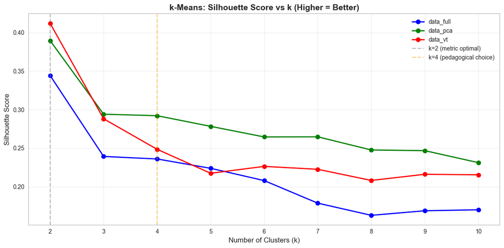

```python
### Visualizing Silhouette Score vs k

plt.figure(figsize=(12, 6))

datasets = [
    (kmeans_results_full, 'data_full', 'blue'),
    (kmeans_results_pca, 'data_pca', 'green'),
    (kmeans_results_vt, 'data_vt', 'red')
]

for results, name, color in datasets:
    plt.plot(results['k'], results['silhouette'], marker='o', label=name,
             linewidth=2, markersize=8, color=color)

plt.axvline(2, color='gray', linestyle='--', alpha=0.5, label='k=2 (metric optimal)')
plt.axvline(4, color='orange', linestyle='--', alpha=0.5, label='k=4 (pedagogical choice)')
plt.xlabel('Number of Clusters (k)', fontsize=12)
plt.ylabel('Silhouette Score', fontsize=12)
plt.title('k-Means: Silhouette Score vs k (Higher = Better)', fontsize=14, fontweight='bold')
plt.legend()
plt.grid(alpha=0.3)
plt.tight_layout()
plt.show()
```

**Silhouette Score Analysis:**

**Why k=2 is suboptimal despite best metrics:**

- Pedagogically oversimplified: Cannot distinguish "efficient learners" from "engaged achievers" or "struggling despite effort" from "disengaged"
- Contradicts Task 4 findings: EDA revealed 4-5 distinct behavioral profiles (engagement × performance quadrants)
- Limited actionability: Binary classification provides minimal insight for targeted interventions

**Decision: k=4 for primary analysis**

We select k=4 as our standard despite lower silhouette scores (0.24-0.29) because: ✓ Aligns with Task 4's engagement × performance framework  
✓ Captures meaningful diversity: high/low engagement × high/low performance  
✓ Provides actionable granularity for educational interventions  
✓ Balances statistical quality with pedagogical interpretability

We'll analyze both k=2 and k=4 to compare metric-optimal vs. domain-informed clustering.

#### Fitting k-Means with k=2 and k=4

It makes sense to visualize both. 2 has the most promising scores, yet it does not promise to differentiate between the students with much nuance, likely resulting in Withdrawn/Fail and Pass/Distinction clusters.

```python
### Fitting k-Means with k=2 and k=4

print("="*70)
print("FITTING FINAL K-MEANS MODELS")
print("="*70)

# Fit k=4 (pedagogical choice)
kmeans_full_k4 = KMeans(n_clusters=4, init='k-means++', n_init=10, random_state=42)
kmeans_pca_k4 = KMeans(n_clusters=4, init='k-means++', n_init=10, random_state=42)
kmeans_vt_k4 = KMeans(n_clusters=4, init='k-means++', n_init=10, random_state=42)

labels_kmeans_full_k4 = kmeans_full_k4.fit_predict(data_full_scaled)
labels_kmeans_pca_k4 = kmeans_pca_k4.fit_predict(data_pca_scaled)
labels_kmeans_vt_k4 = kmeans_vt_k4.fit_predict(data_vt_scaled)

# Fit k=2 (metric optimal)
kmeans_full_k2 = KMeans(n_clusters=2, init='k-means++', n_init=10, random_state=42)
kmeans_pca_k2 = KMeans(n_clusters=2, init='k-means++', n_init=10, random_state=42)
kmeans_vt_k2 = KMeans(n_clusters=2, init='k-means++', n_init=10, random_state=42)

labels_kmeans_full_k2 = kmeans_full_k2.fit_predict(data_full_scaled)
labels_kmeans_pca_k2 = kmeans_pca_k2.fit_predict(data_pca_scaled)
labels_kmeans_vt_k2 = kmeans_vt_k2.fit_predict(data_vt_scaled)

print("\n✓ k-Means clustering complete for k=2 and k=4")

print("\nk=4 Results:")
print(f"  data_full: Silhouette={silhouette_score(data_full_scaled, labels_kmeans_full_k4):.3f}, "
      f"Sizes={dict(sorted(Counter(labels_kmeans_full_k4).items()))}")
print(f"  data_pca:  Silhouette={silhouette_score(data_pca_scaled, labels_kmeans_pca_k4):.3f}, "
      f"Sizes={dict(sorted(Counter(labels_kmeans_pca_k4).items()))}")
print(f"  data_vt:   Silhouette={silhouette_score(data_vt_scaled, labels_kmeans_vt_k4):.3f}, "
      f"Sizes={dict(sorted(Counter(labels_kmeans_vt_k4).items()))}")

print("\nk=2 Results:")
print(f"  data_full: Silhouette={silhouette_score(data_full_scaled, labels_kmeans_full_k2):.3f}, "
      f"Sizes={dict(sorted(Counter(labels_kmeans_full_k2).items()))}")
print(f"  data_pca:  Silhouette={silhouette_score(data_pca_scaled, labels_kmeans_pca_k2):.3f}, "
      f"Sizes={dict(sorted(Counter(labels_kmeans_pca_k2).items()))}")
print(f"  data_vt:   Silhouette={silhouette_score(data_vt_scaled, labels_kmeans_vt_k2):.3f}, "
      f"Sizes={dict(sorted(Counter(labels_kmeans_vt_k2).items()))}")

print("="*70)
```

```
======================================================================
FITTING FINAL K-MEANS MODELS
======================================================================

✓ k-Means clustering complete for k=2 and k=4

k=4 Results:
  data_full: Silhouette=0.236, Sizes={np.int32(0): 1249, np.int32(1): 1303, np.int32(2): 2596, np.int32(3): 1062}
  data_pca:  Silhouette=0.292, Sizes={np.int32(0): 2603, np.int32(1): 1323, np.int32(2): 1300, np.int32(3): 984}
  data_vt:   Silhouette=0.249, Sizes={np.int32(0): 1318, np.int32(1): 1340, np.int32(2): 1246, np.int32(3): 2306}

k=2 Results:
  data_full: Silhouette=0.344, Sizes={np.int32(0): 3933, np.int32(1): 2277}
  data_pca:  Silhouette=0.390, Sizes={np.int32(0): 2279, np.int32(1): 3931}
  data_vt:   Silhouette=0.412, Sizes={np.int32(0): 2353, np.int32(1): 3857}
======================================================================
```

#### Visualize Silhouette Scores

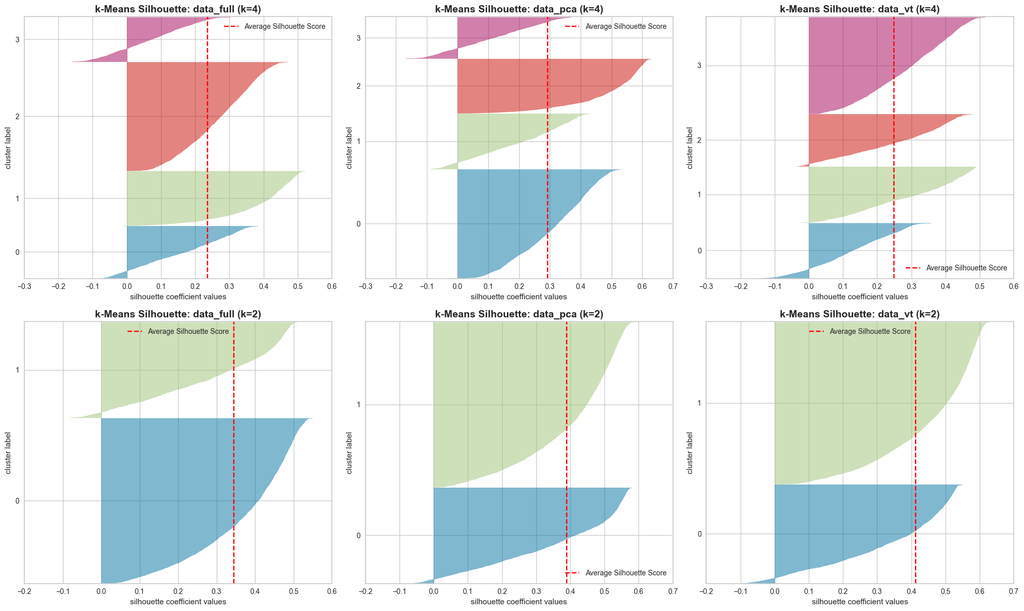

```python
### Silhouette visualization for k=2 and k=4

fig, axes = plt.subplots(2, 3, figsize=(20, 12))

# ============ ROW 1: k=4 ============

visualizer_full_k4 = SilhouetteVisualizer(kmeans_full_k4, colors='yellowbrick', ax=axes[0, 0])
visualizer_full_k4.fit(data_full_scaled)
visualizer_full_k4.finalize()
axes[0, 0].set_title('k-Means Silhouette: data_full (k=4)', fontsize=14, fontweight='bold')

visualizer_pca_k4 = SilhouetteVisualizer(kmeans_pca_k4, colors='yellowbrick', ax=axes[0, 1])
visualizer_pca_k4.fit(data_pca_scaled)
visualizer_pca_k4.finalize()
axes[0, 1].set_title('k-Means Silhouette: data_pca (k=4)', fontsize=14, fontweight='bold')

visualizer_vt_k4 = SilhouetteVisualizer(kmeans_vt_k4, colors='yellowbrick', ax=axes[0, 2])
visualizer_vt_k4.fit(data_vt_scaled)
visualizer_vt_k4.finalize()
axes[0, 2].set_title('k-Means Silhouette: data_vt (k=4)', fontsize=14, fontweight='bold')

# ============ ROW 2: k=2 ============

visualizer_full_k2 = SilhouetteVisualizer(kmeans_full_k2, colors='yellowbrick', ax=axes[1, 0])
visualizer_full_k2.fit(data_full_scaled)
visualizer_full_k2.finalize()
axes[1, 0].set_title('k-Means Silhouette: data_full (k=2)', fontsize=14, fontweight='bold')

visualizer_pca_k2 = SilhouetteVisualizer(kmeans_pca_k2, colors='yellowbrick', ax=axes[1, 1])
visualizer_pca_k2.fit(data_pca_scaled)
visualizer_pca_k2.finalize()
axes[1, 1].set_title('k-Means Silhouette: data_pca (k=2)', fontsize=14, fontweight='bold')

visualizer_vt_k2 = SilhouetteVisualizer(kmeans_vt_k2, colors='yellowbrick', ax=axes[1, 2])
visualizer_vt_k2.fit(data_vt_scaled)
visualizer_vt_k2.finalize()
axes[1, 2].set_title('k-Means Silhouette: data_vt (k=2)', fontsize=14, fontweight='bold')

plt.tight_layout()
plt.show()
```

**k=4 (Pedagogical Choice):**

**k=2 (Metric Optimal):**

- Thicker, more uniform silhouette bars indicate tighter clusters
- Higher average silhouette scores (dashed red line further right)
- More balanced cluster sizes
- Cleaner separation but at cost of oversimplification

#### Visualize in 2D Scatterplots

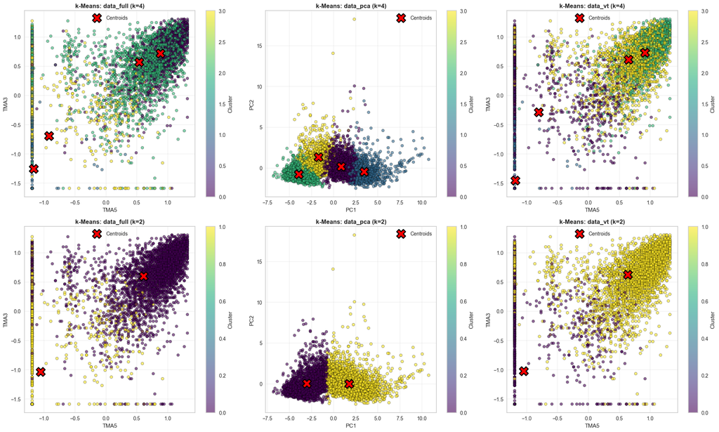

```python
### Visualizing k=2 and k=4 clusters in 2D space

fig, axes = plt.subplots(2, 3, figsize=(20, 12))

# Get top 2 variance features (only need to calculate once)
top_2_features_full = data_full_scaled.var().nlargest(2).index
centroid_idx_0_full = data_full_scaled.columns.get_loc(top_2_features_full[0])
centroid_idx_1_full = data_full_scaled.columns.get_loc(top_2_features_full[1])

top_2_features_vt = data_vt_scaled.var().nlargest(2).index
centroid_idx_0_vt = data_vt_scaled.columns.get_loc(top_2_features_vt[0])
centroid_idx_1_vt = data_vt_scaled.columns.get_loc(top_2_features_vt[1])

# ============ ROW 1: k=4 ============

# data_full (k=4)
scatter1 = axes[0, 0].scatter(data_full_scaled[top_2_features_full[0]],
                               data_full_scaled[top_2_features_full[1]],
                               c=labels_kmeans_full_k4, cmap='viridis', alpha=0.6, s=30,
                               edgecolors='black', linewidth=0.5)
axes[0, 0].scatter(kmeans_full_k4.cluster_centers_[:, centroid_idx_0_full],
                    kmeans_full_k4.cluster_centers_[:, centroid_idx_1_full],
                    c='red', marker='X', s=300, edgecolors='black', linewidth=2,
                    label='Centroids', zorder=10)
axes[0, 0].set_xlabel(top_2_features_full[0], fontsize=11)
axes[0, 0].set_ylabel(top_2_features_full[1], fontsize=11)
axes[0, 0].set_title('k-Means: data_full (k=4)', fontsize=12, fontweight='bold')
axes[0, 0].legend()
axes[0, 0].grid(alpha=0.3)
plt.colorbar(scatter1, ax=axes[0, 0], label='Cluster')

# data_pca (k=4)
scatter2 = axes[0, 1].scatter(data_pca_scaled['PC1'], data_pca_scaled['PC2'],
                               c=labels_kmeans_pca_k4, cmap='viridis', alpha=0.6, s=30,
                               edgecolors='black', linewidth=0.5)
axes[0, 1].scatter(kmeans_pca_k4.cluster_centers_[:, 0],
                    kmeans_pca_k4.cluster_centers_[:, 1],
                    c='red', marker='X', s=300, edgecolors='black', linewidth=2,
                    label='Centroids', zorder=10)
axes[0, 1].set_xlabel('PC1', fontsize=11)
axes[0, 1].set_ylabel('PC2', fontsize=11)
axes[0, 1].set_title('k-Means: data_pca (k=4)', fontsize=12, fontweight='bold')
axes[0, 1].legend()
axes[0, 1].grid(alpha=0.3)
plt.colorbar(scatter2, ax=axes[0, 1], label='Cluster')

# data_vt (k=4)
scatter3 = axes[0, 2].scatter(data_vt_scaled[top_2_features_vt[0]],
                               data_vt_scaled[top_2_features_vt[1]],
                               c=labels_kmeans_vt_k4, cmap='viridis', alpha=0.6, s=30,
                               edgecolors='black', linewidth=0.5)
axes[0, 2].scatter(kmeans_vt_k4.cluster_centers_[:, centroid_idx_0_vt],
                    kmeans_vt_k4.cluster_centers_[:, centroid_idx_1_vt],
                    c='red', marker='X', s=300, edgecolors='black', linewidth=2,
                    label='Centroids', zorder=10)
axes[0, 2].set_xlabel(top_2_features_vt[0], fontsize=11)
axes[0, 2].set_ylabel(top_2_features_vt[1], fontsize=11)
axes[0, 2].set_title('k-Means: data_vt (k=4)', fontsize=12, fontweight='bold')
axes[0, 2].legend()
axes[0, 2].grid(alpha=0.3)
plt.colorbar(scatter3, ax=axes[0, 2], label='Cluster')

# ============ ROW 2: k=2 ============

# data_full (k=2)
scatter4 = axes[1, 0].scatter(data_full_scaled[top_2_features_full[0]],
                               data_full_scaled[top_2_features_full[1]],
                               c=labels_kmeans_full_k2, cmap='viridis', alpha=0.6, s=30,
                               edgecolors='black', linewidth=0.5)
axes[1, 0].scatter(kmeans_full_k2.cluster_centers_[:, centroid_idx_0_full],
                    kmeans_full_k2.cluster_centers_[:, centroid_idx_1_full],
                    c='red', marker='X', s=300, edgecolors='black', linewidth=2,
                    label='Centroids', zorder=10)
axes[1, 0].set_xlabel(top_2_features_full[0], fontsize=11)
axes[1, 0].set_ylabel(top_2_features_full[1], fontsize=11)
axes[1, 0].set_title('k-Means: data_full (k=2)', fontsize=12, fontweight='bold')
axes[1, 0].legend()
axes[1, 0].grid(alpha=0.3)
plt.colorbar(scatter4, ax=axes[1, 0], label='Cluster')

# data_pca (k=2)
scatter5 = axes[1, 1].scatter(data_pca_scaled['PC1'], data_pca_scaled['PC2'],
                               c=labels_kmeans_pca_k2, cmap='viridis', alpha=0.6, s=30,
                               edgecolors='black', linewidth=0.5)
axes[1, 1].scatter(kmeans_pca_k2.cluster_centers_[:, 0],
                    kmeans_pca_k2.cluster_centers_[:, 1],
                    c='red', marker='X', s=300, edgecolors='black', linewidth=2,
                    label='Centroids', zorder=10)
axes[1, 1].set_xlabel('PC1', fontsize=11)
axes[1, 1].set_ylabel('PC2', fontsize=11)
axes[1, 1].set_title('k-Means: data_pca (k=2)', fontsize=12, fontweight='bold')
axes[1, 1].legend()
axes[1, 1].grid(alpha=0.3)
plt.colorbar(scatter5, ax=axes[1, 1], label='Cluster')

# data_vt (k=2)
scatter6 = axes[1, 2].scatter(data_vt_scaled[top_2_features_vt[0]],
                               data_vt_scaled[top_2_features_vt[1]],
                               c=labels_kmeans_vt_k2, cmap='viridis', alpha=0.6, s=30,
                               edgecolors='black', linewidth=0.5)
axes[1, 2].scatter(kmeans_vt_k2.cluster_centers_[:, centroid_idx_0_vt],
                    kmeans_vt_k2.cluster_centers_[:, centroid_idx_1_vt],
                    c='red', marker='X', s=300, edgecolors='black', linewidth=2,
                    label='Centroids', zorder=10)
axes[1, 2].set_xlabel(top_2_features_vt[0], fontsize=11)
axes[1, 2].set_ylabel(top_2_features_vt[1], fontsize=11)
axes[1, 2].set_title('k-Means: data_vt (k=2)', fontsize=12, fontweight='bold')
axes[1, 2].legend()
axes[1, 2].grid(alpha=0.3)
plt.colorbar(scatter6, ax=axes[1, 2], label='Cluster')

plt.tight_layout()
plt.show()
```

- As we can see here most clustersand centroid positions are not very logical. The best intuitively understandable version is `data_pca`with k=4 or k=2. We will therefore take a closer look at the k=4 version of this.

#### Analyzing outcome distributions within clusters (using data_pca k=4)

```
======================================================================
CLUSTER OUTCOME ANALYSIS: Final Results Distribution (data_pca, k=4)
======================================================================

======================================================================
CLUSTER 0 (n=2603)
======================================================================

Outcome Distribution:
  Distinction :  248 (  9.5%)
  Pass        : 1971 ( 75.7%)
  Fail        :  324 ( 12.4%)
  Withdrawn   :   60 (  2.3%)

  → Dominant outcome: Pass (75.7%)

======================================================================
CLUSTER 1 (n=1323)
======================================================================

Outcome Distribution:
  Distinction :  421 ( 31.8%)
  Pass        :  844 ( 63.8%)
  Fail        :   49 (  3.7%)
  Withdrawn   :    9 (  0.7%)

  → Dominant outcome: Pass (63.8%)

======================================================================
CLUSTER 2 (n=1300)
======================================================================

Outcome Distribution:
  Distinction :    0 (  0.0%)
  Pass        :    1 (  0.1%)
  Fail        :  631 ( 48.5%)
  Withdrawn   :  668 ( 51.4%)

  → Dominant outcome: Withdrawn (51.4%)

======================================================================
CLUSTER 3 (n=984)
======================================================================

Outcome Distribution:
  Distinction :    0 (  0.0%)
  Pass        :  161 ( 16.4%)
  Fail        :  429 ( 43.6%)
  Withdrawn   :  394 ( 40.0%)

  → Dominant outcome: Fail (43.6%)

======================================================================
OVERALL DATASET DISTRIBUTION (n=6210)
======================================================================
  Distinction :  669 ( 10.8%)
  Pass        : 2977 ( 47.9%)
  Fail        : 1433 ( 23.1%)
  Withdrawn   : 1131 ( 18.2%)

======================================================================
```

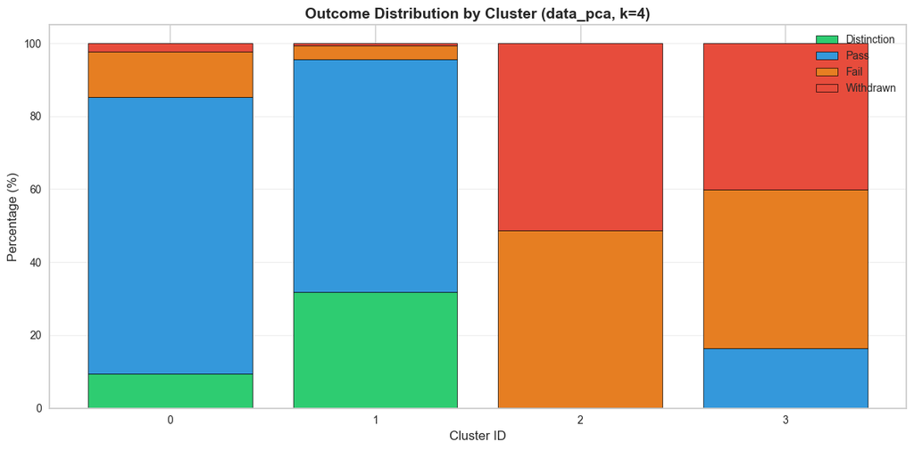

```python
### Analyzing outcome distributions within clusters (using data_pca k=4)

print("="*70)
print("CLUSTER OUTCOME ANALYSIS: Final Results Distribution (data_pca, k=4)")
print("="*70)

# Extract outcome from index (last digit: 1=Withdrawn, 2=Fail, 3=Pass, 4=Distinction)
def extract_outcome(index_value):
    outcome_code = str(index_value)[-1]
    outcome_map = {'1': 'Withdrawn', '2': 'Fail', '3': 'Pass', '4': 'Distinction'}
    return outcome_map.get(outcome_code, 'Unknown')

# Add outcomes to dataframe
data_full_with_clusters = data_full.copy()
data_full_with_clusters['cluster_pca_k4'] = labels_kmeans_pca_k4
data_full_with_clusters['outcome'] = data_full_with_clusters.index.map(extract_outcome)

# Analyze each cluster
for cluster_id in sorted(set(labels_kmeans_pca_k4)):
    cluster_data = data_full_with_clusters[data_full_with_clusters['cluster_pca_k4'] == cluster_id]
    outcome_counts = cluster_data['outcome'].value_counts()
    cluster_size = len(cluster_data)

    print(f"\n{'='*70}")
    print(f"CLUSTER {cluster_id} (n={cluster_size})")
    print(f"{'='*70}")
    print(f"\nOutcome Distribution:")

    for outcome in ['Distinction', 'Pass', 'Fail', 'Withdrawn']:
        count = outcome_counts.get(outcome, 0)
        percentage = (count / cluster_size) * 100
        print(f"  {outcome:12s}: {count:4d} ({percentage:5.1f}%)")

    # Dominant outcome
    dominant_outcome = outcome_counts.idxmax()
    dominant_pct = (outcome_counts.max() / cluster_size) * 100
    print(f"\n  → Dominant outcome: {dominant_outcome} ({dominant_pct:.1f}%)")

# Overall distribution for comparison
print(f"\n{'='*70}")
print(f"OVERALL DATASET DISTRIBUTION (n={len(data_full_with_clusters)})")
print(f"{'='*70}")
overall_counts = data_full_with_clusters['outcome'].value_counts()
for outcome in ['Distinction', 'Pass', 'Fail', 'Withdrawn']:
    count = overall_counts.get(outcome, 0)
    percentage = (count / len(data_full_with_clusters)) * 100
    print(f"  {outcome:12s}: {count:4d} ({percentage:5.1f}%)")

print("\n" + "="*70)

# Visualization: Stacked bar chart
fig, ax = plt.subplots(figsize=(12, 6))

outcomes = ['Distinction', 'Pass', 'Fail', 'Withdrawn']
colors = {'Distinction': '#2ecc71', 'Pass': '#3498db', 'Fail': '#e67e22', 'Withdrawn': '#e74c3c'}

cluster_ids = sorted(set(labels_kmeans_pca_k4))
bottoms = np.zeros(len(cluster_ids))

for outcome in outcomes:
    percentages = []
    for cluster_id in cluster_ids:
        cluster_data = data_full_with_clusters[data_full_with_clusters['cluster_pca_k4'] == cluster_id]
        count = (cluster_data['outcome'] == outcome).sum()
        pct = (count / len(cluster_data)) * 100
        percentages.append(pct)

    ax.bar(cluster_ids, percentages, bottom=bottoms, label=outcome,
           color=colors[outcome], edgecolor='black', linewidth=0.5)
    bottoms += percentages

ax.set_xlabel('Cluster ID', fontsize=12)
ax.set_ylabel('Percentage (%)', fontsize=12)
ax.set_title('Outcome Distribution by Cluster (data_pca, k=4)', fontsize=14, fontweight='bold')
ax.set_xticks(cluster_ids)
ax.legend(loc='upper right')
ax.grid(axis='y', alpha=0.3)
plt.tight_layout()
plt.show()
```

## 7.2 OPTICS Clustering

**Parameters:**

**1. `min_samples` = 2% of dataset size (~124 students)**

- **Purpose:** Minimum points needed to form a dense neighborhood
- **Rationale:**
  - Too low (e.g., 5): Every small group becomes a cluster → over-fragmentation
  - Too high (e.g., 500): Only massive groups detected → misses meaningful subgroups
  - 2% heuristic balances sensitivity to genuine behavioral patterns vs. random noise
  - For 6,210 students: ~124 students represents meaningful cohort size for intervention planning

**2. `max_eps` = ∞ (unbounded)**

- **Purpose:** Maximum neighborhood radius to consider
- **Rationale:** No artificial distance limit—let OPTICS explore full density structure
- **Benefit:** Reachability plot reveals natural density breaks at all scales

**3. metric = 'euclidean'**

- Standard for continuous data: Captures geometric similarity in behavioral feature space
- OPTICS compatibility: Works naturally with density-based clustering on numerical data
- Transparency: Most intuitively understandable distance norm

```python
### Applying OPTICS with epsilon threshold clustering

from sklearn.cluster import OPTICS, cluster_optics_dbscan

print("="*70)
print("OPTICS DENSITY-BASED CLUSTERING")
print("="*70)

# Set min_samples to ~2% of dataset
min_samples = max(5, int(len(data_pca_scaled) * 0.02))

print(f"Parameters:")
print(f"  min_samples: {min_samples} (~2% of dataset)")
print(f"  max_eps: inf (unbounded)")
print(f"  metric: euclidean")
print("="*70)

# Fit OPTICS to create reachability ordering
optics_pca = OPTICS(min_samples=min_samples, max_eps=np.inf, metric='euclidean')
optics_pca.fit(data_pca_scaled)

# Analyze reachability distribution to find epsilon threshold
reachability_valid = optics_pca.reachability_[optics_pca.reachability_ != np.inf]

print(f"\nReachability Distance Statistics:")
print(f"  Min:     {reachability_valid.min():.3f}")
print(f"  10th %:  {np.percentile(reachability_valid, 10):.3f}")
print(f"  25th %:  {np.percentile(reachability_valid, 25):.3f}")
print(f"  Median:  {np.percentile(reachability_valid, 50):.3f}")
print(f"  75th %:  {np.percentile(reachability_valid, 75):.3f}")
print(f"  90th %:  {np.percentile(reachability_valid, 90):.3f}")
print(f"  95th %:  {np.percentile(reachability_valid, 95):.3f}")
print(f"  Max:     {reachability_valid.max():.3f}")

# Test different percentile thresholds to see cluster distribution
print(f"\n" + "="*70)
print("TESTING DIFFERENT EPSILON THRESHOLDS")
print("="*70)

percentiles = [10, 25, 50, 75, 90, 95]

for p in percentiles:
    eps = np.percentile(reachability_valid, p)

    labels_test = cluster_optics_dbscan(
        reachability=optics_pca.reachability_,
        core_distances=optics_pca.core_distances_,
        ordering=optics_pca.ordering_,
        eps=eps
    )

    n_clusters = len(set(labels_test)) - (1 if -1 in labels_test else 0)
    n_noise = list(labels_test).count(-1)

    print(f"\n{p}th percentile (ε={eps:.3f}):")
    print(f"  Clusters: {n_clusters}, Noise: {n_noise} ({n_noise/len(labels_test)*100:.1f}%)")

    if n_clusters > 0:
        cluster_sizes = {k: v for k, v in sorted(Counter(labels_test).items()) if k != -1}
        print(f"  Cluster sizes: {cluster_sizes}")

# Use 50th percentile as epsilon threshold (median density)
eps_threshold = np.percentile(reachability_valid, 50)

# Extract clusters using epsilon cut
labels_optics_pca = cluster_optics_dbscan(
    reachability=optics_pca.reachability_,
    core_distances=optics_pca.core_distances_,
    ordering=optics_pca.ordering_,
    eps=eps_threshold
)

n_clusters_pca = len(set(labels_optics_pca)) - (1 if -1 in labels_optics_pca else 0)
n_noise_pca = list(labels_optics_pca).count(-1)
```

[output not shown]

- We select the SELECTED: 50th percentile epsilon (median) ε=1.044.
- WIth this setting the resulting clusters are large and relatively dense. Other clusters produce more noise or small meaningless clusters (75th percentile).

#### Applying and Visualizing selected OPTICS parameters across datasets

```python
### Applying OPTICS to all three datasets

print("\nApplying OPTICS to all datasets...")
print("=" * 60)

# data_full
optics_full = OPTICS(min_samples=min_samples, max_eps=np.inf, metric='euclidean')
optics_full.fit(data_full_scaled)
reachability_full = optics_full.reachability_[optics_full.reachability_ != np.inf]
eps_full = np.percentile(reachability_full, 50)
labels_optics_full = cluster_optics_dbscan(
    reachability=optics_full.reachability_,
    core_distances=optics_full.core_distances_,
    ordering=optics_full.ordering_,
    eps=eps_full
)
n_clusters_full = len(set(labels_optics_full)) - (1 if -1 in labels_optics_full else 0)
n_noise_full = list(labels_optics_full).count(-1)

# data_vt
optics_vt = OPTICS(min_samples=min_samples, max_eps=np.inf, metric='euclidean')
optics_vt.fit(data_vt_scaled)
reachability_vt = optics_vt.reachability_[optics_vt.reachability_ != np.inf]
eps_vt = np.percentile(reachability_vt, 50)
labels_optics_vt = cluster_optics_dbscan(
    reachability=optics_vt.reachability_,
    core_distances=optics_vt.core_distances_,
    ordering=optics_vt.ordering_,
    eps=eps_vt
)
n_clusters_vt = len(set(labels_optics_vt)) - (1 if -1 in labels_optics_vt else 0)
n_noise_vt = list(labels_optics_vt).count(-1)

# Print summary
print(f"\ndata_full:  {n_clusters_full} clusters, {n_noise_full} noise ({n_noise_full/len(labels_optics_full)*100:.1f}%), ε={eps_full:.3f}")
print(f"data_pca:   {n_clusters_pca} clusters, {n_noise_pca} noise ({n_noise_pca/len(labels_optics_pca)*100:.1f}%), ε={eps_threshold:.3f}")
print(f"data_vt:    {n_clusters_vt} clusters, {n_noise_vt} noise ({n_noise_vt/len(labels_optics_vt)*100:.1f}%), ε={eps_vt:.3f}")
```

```
Applying OPTICS to all datasets...
============================================================

data_full:  2 clusters, 3103 noise (50.0%), ε=1.488
data_pca:   2 clusters, 3102 noise (50.0%), ε=1.044
data_vt:    3 clusters, 3101 noise (49.9%), ε=0.999
```

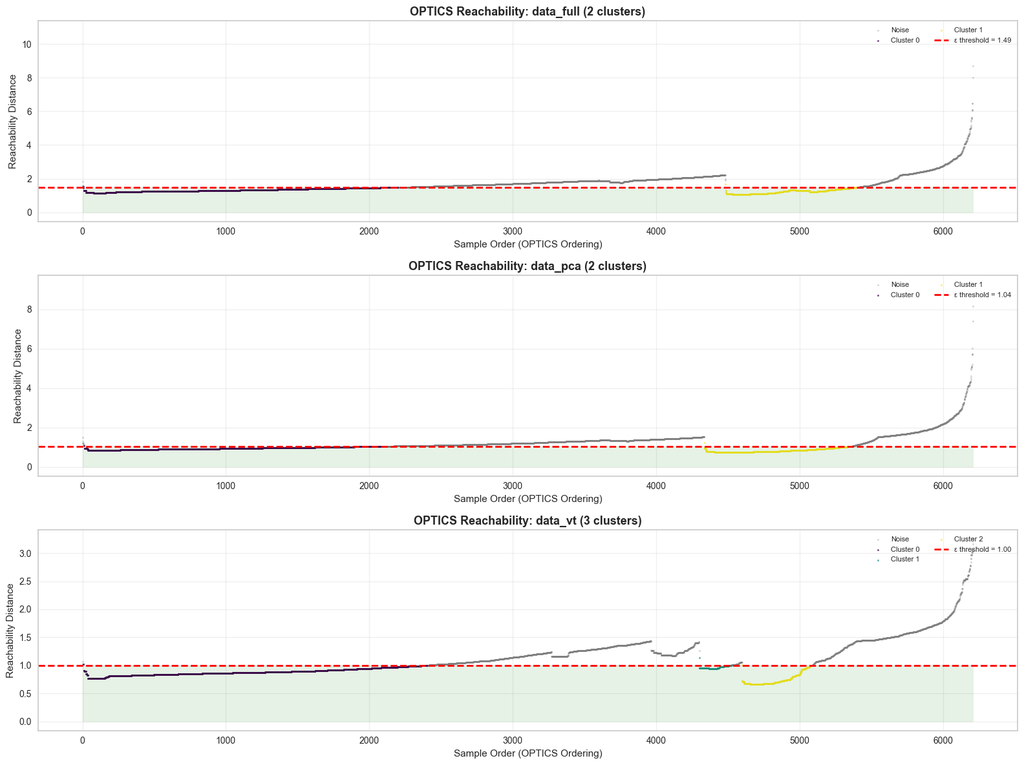

```
Reachability Plot Interpretation:
----------------------------------------------------------------------
• Points BELOW red line = Dense clusters
• Points ABOVE red line = Noise/outliers
• Valleys in the plot = Dense regions (clusters)
• Peaks = Transitions between clusters or sparse areas
```

```python
### Visualizing OPTICS reachability plots

fig, axes = plt.subplots(3, 1, figsize=(16, 12))

def plot_reachability(ax, optics_model, labels, eps, title):
    """Plot reachability diagram with cluster coloring"""
    space = np.arange(len(labels))
    reachability = optics_model.reachability_[optics_model.ordering_]
    labels_ordered = labels[optics_model.ordering_]

    # Plot with cluster colors
    n_clusters = len(set(labels)) - (1 if -1 in labels else 0)
    if n_clusters > 0:
        colors_map = plt.cm.viridis(np.linspace(0, 1, n_clusters))

        for cluster_id in sorted(set(labels)):
            if cluster_id == -1:
                mask = labels_ordered == cluster_id
                ax.scatter(space[mask], reachability[mask],
                          c='gray', alpha=0.3, s=3, label='Noise')
            else:
                mask = labels_ordered == cluster_id
                ax.scatter(space[mask], reachability[mask],
                          c=[colors_map[cluster_id]], alpha=0.7, s=3,
                          label=f'Cluster {cluster_id}')

    # Epsilon threshold line
    ax.axhline(y=eps, color='red', linestyle='--', linewidth=2,
               label=f'ε threshold = {eps:.2f}')
    ax.fill_between(space, 0, eps, alpha=0.1, color='green')

    ax.set_ylabel('Reachability Distance', fontsize=11)
    ax.set_xlabel('Sample Order (OPTICS Ordering)', fontsize=11)
    ax.set_title(title, fontsize=13, fontweight='bold')
    ax.legend(loc='upper right', fontsize=8, ncol=2)
    ax.grid(alpha=0.3)

plot_reachability(axes[0], optics_full, labels_optics_full, eps_full,
                  f'OPTICS Reachability: data_full ({n_clusters_full} clusters)')
plot_reachability(axes[1], optics_pca, labels_optics_pca, eps_threshold,
                  f'OPTICS Reachability: data_pca ({n_clusters_pca} clusters)')
plot_reachability(axes[2], optics_vt, labels_optics_vt, eps_vt,
                  f'OPTICS Reachability: data_vt ({n_clusters_vt} clusters)')

plt.tight_layout()
plt.show()

print("\nReachability Plot Interpretation:")
print("-" * 70)
print("• Points BELOW red line = Dense clusters")
print("• Points ABOVE red line = Noise/outliers")
print("• Valleys in the plot = Dense regions (clusters)")
print("• Peaks = Transitions between clusters or sparse areas")
```

- We can see that no large valleys are created. There are for the most part continuosly points with similar features differences across the denser regions of the dataset.

#### Visualize with Scatterplot (2D)

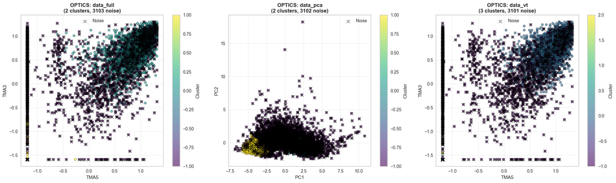

```python
### Visualizing OPTICS clusters in 2D space

fig, axes = plt.subplots(1, 3, figsize=(20, 6))

# data_full
scatter1 = axes[0].scatter(data_full_scaled[top_2_features_full[0]],
                           data_full_scaled[top_2_features_full[1]],
                           c=labels_optics_full, cmap='viridis', alpha=0.6, s=30,
                           edgecolors='black', linewidth=0.5)
noise_mask_full = labels_optics_full == -1
axes[0].scatter(data_full_scaled.loc[noise_mask_full, top_2_features_full[0]],
                data_full_scaled.loc[noise_mask_full, top_2_features_full[1]],
                c='black', marker='x', s=50, alpha=0.4, label='Noise')
axes[0].set_xlabel(top_2_features_full[0], fontsize=11)
axes[0].set_ylabel(top_2_features_full[1], fontsize=11)
axes[0].set_title(f'OPTICS: data_full\n({n_clusters_full} clusters, {n_noise_full} noise)',
                  fontsize=12, fontweight='bold')
axes[0].legend()
axes[0].grid(alpha=0.3)
plt.colorbar(scatter1, ax=axes[0], label='Cluster')

# data_pca
scatter2 = axes[1].scatter(data_pca_scaled['PC1'], data_pca_scaled['PC2'],
                           c=labels_optics_pca, cmap='viridis', alpha=0.6, s=30,
                           edgecolors='black', linewidth=0.5)
noise_mask_pca = labels_optics_pca == -1
axes[1].scatter(data_pca_scaled.loc[noise_mask_pca, 'PC1'],
                data_pca_scaled.loc[noise_mask_pca, 'PC2'],
                c='black', marker='x', s=50, alpha=0.4, label='Noise')
axes[1].set_xlabel('PC1', fontsize=11)
axes[1].set_ylabel('PC2', fontsize=11)
axes[1].set_title(f'OPTICS: data_pca\n({n_clusters_pca} clusters, {n_noise_pca} noise)',
                  fontsize=12, fontweight='bold')
axes[1].legend()
axes[1].grid(alpha=0.3)
plt.colorbar(scatter2, ax=axes[1], label='Cluster')

# data_vt
scatter3 = axes[2].scatter(data_vt_scaled[top_2_features_vt[0]],
                           data_vt_scaled[top_2_features_vt[1]],
                           c=labels_optics_vt, cmap='viridis', alpha=0.6, s=30,
                           edgecolors='black', linewidth=0.5)
noise_mask_vt = labels_optics_vt == -1
axes[2].scatter(data_vt_scaled.loc[noise_mask_vt, top_2_features_vt[0]],
                data_vt_scaled.loc[noise_mask_vt, top_2_features_vt[1]],
                c='black', marker='x', s=50, alpha=0.4, label='Noise')
axes[2].set_xlabel(top_2_features_vt[0], fontsize=11)
axes[2].set_ylabel(top_2_features_vt[1], fontsize=11)
axes[2].set_title(f'OPTICS: data_vt\n({n_clusters_vt} clusters, {n_noise_vt} noise)',
                  fontsize=12, fontweight='bold')
axes[2].legend()
axes[2].grid(alpha=0.3)
plt.colorbar(scatter3, ax=axes[2], label='Cluster')

plt.tight_layout()
plt.show()
```

OPTICS identified density-based clusters by analyzing the reachability distance structure. Using the median reachability as an epsilon threshold, we extracted clusters representing dense student behavioral patterns, with remaining points labeled as noise (atypical students).

**Key Findings:**

- **Cluster count**: Automatically discovered based on density structure (no predetermined k)
- **Noise points**: Students with unusual behavioral patterns that don't fit standard density regions
- **Reachability plots**: Valleys indicate dense clusters; peaks show transitions/sparse areas

The amount of noise for this clustering approach is very high (as we see above). It is therefore not the most promising method for the given dataset.

## 7.3 Hierarchical Agglomerative Clustering (HAC)

**Linkage Methods:**

- **Ward**: Minimizes within-cluster variance (good for compact clusters)
- **Average**: Average distance between all pairs (balanced approach)
- **Complete**: Maximum distance between clusters (avoids chaining)
- **Single**: Minimum distance between clusters (can create long chains)

We will compare these as parameters, but they create so much chaos in the dendogram that the decision for ward linkage is fixed. We will only look at an example how the different linkages would look in 2D space for `data_pca`.

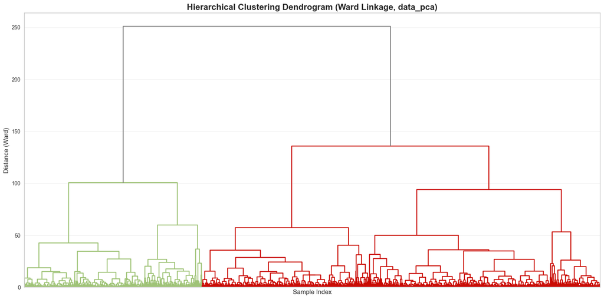

```python
# Create linkage matrix for dendrogram (using Ward method, because other methods created complete chaos in the dendogram)
# We use data_pca for clearer visualization due to lower dimensionality
linkage_matrix = linkage(data_pca_scaled, method='ward', metric='euclidean')

# Plot dendrogram
plt.figure(figsize=(16, 8))
dendrogram(linkage_matrix,
           no_labels=True,
           color_threshold=0.7*max(linkage_matrix[:, 2]),
           above_threshold_color='gray')
plt.title('Hierarchical Clustering Dendrogram (Ward Linkage, data_pca)',
          fontsize=16, fontweight='bold')
plt.xlabel('Sample Index', fontsize=12)
plt.ylabel('Distance (Ward)', fontsize=12)
plt.legend()
plt.grid(alpha=0.3, axis='y')
plt.tight_layout()
plt.show()
```

- We could go with the same k as in k-means but with this linkage k=9 does look promising (cutting at roughly distance 45)

#### Looking at different linkages for `data_pca` with clusters = 9

[figure not shown]

```python
### Comparing different linkage methods for HAC (k=9)

linkage_methods = ['ward', 'average', 'complete', 'single']
n_clusters_test = 9  # Test with k=9 to match our chosen cluster count

results_hac = {}

# Fit HAC with each linkage method
for method in linkage_methods:
    hac = AgglomerativeClustering(n_clusters=n_clusters_test,
                                   linkage=method,
                                   metric='euclidean')
    labels = hac.fit_predict(data_pca_scaled)

    # Store labels for visualization
    results_hac[method] = {
        'labels': labels
    }

# Visualize all four linkage methods side-by-side
fig, axes = plt.subplots(2, 2, figsize=(16, 14))
axes = axes.ravel()

for idx, method in enumerate(linkage_methods):
    labels = results_hac[method]['labels']

    # Plot clusters in PC1-PC2 space
    scatter = axes[idx].scatter(data_pca_scaled['PC1'], data_pca_scaled['PC2'],
                                c=labels, cmap='viridis', alpha=0.6, s=30,
                                edgecolors='black', linewidth=0.5)
    axes[idx].set_xlabel('PC1', fontsize=11)
    axes[idx].set_ylabel('PC2', fontsize=11)
    axes[idx].set_title(f'HAC: {method.capitalize()} Linkage (k={n_clusters_test})',
                        fontsize=12, fontweight='bold')
    axes[idx].grid(alpha=0.3)
    plt.colorbar(scatter, ax=axes[idx], label='Cluster')

plt.tight_layout()
plt.show()
```

- With ward linkage it looks like we could create a real density clustering from `data_pca`. With the other linkage options it does look less promising.

#### Creating HAC clusterings with ward linkage and k=9 in the different datasets:

```python
### Use Ward linkage with optimal k for all datasets

# Set k
optimal_k_hac = 9

# setup clustering
hac_full = AgglomerativeClustering(n_clusters=optimal_k_hac, linkage='ward', metric='euclidean')
hac_pca = AgglomerativeClustering(n_clusters=optimal_k_hac, linkage='ward', metric='euclidean')
hac_vt = AgglomerativeClustering(n_clusters=optimal_k_hac, linkage='ward', metric='euclidean')

# Apply Clustering, get labels
labels_hac_full = hac_full.fit_predict(data_full_scaled)
labels_hac_pca = hac_pca.fit_predict(data_pca_scaled)
labels_hac_vt = hac_vt.fit_predict(data_vt_scaled)

# Print results
print(" HAC clustering complete for all datasets")
print(f"  Using: Ward linkage, k={optimal_k_hac}")
print(f"\nCluster sizes:")
print(f"  data_full: {dict(Counter(labels_hac_full))}")
print(f"  data_pca:  {dict(Counter(labels_hac_pca))}")
print(f"  data_vt:   {dict(Counter(labels_hac_vt))}")
```

```
HAC clustering complete for all datasets
  Using: Ward linkage, k=9

Cluster sizes:
  data_full: {np.int64(8): 404, np.int64(4): 544, np.int64(1): 1644, np.int64(6): 602, np.int64(5): 725, np.int64(0): 941, np.int64(2): 1208, np.int64(7): 70, np.int64(3): 72}
  data_pca:  {np.int64(4): 1581, np.int64(5): 545, np.int64(2): 79, np.int64(0): 1294, np.int64(3): 371, np.int64(1): 446, np.int64(8): 471, np.int64(6): 1356, np.int64(7): 67}
  data_vt:   {np.int64(0): 840, np.int64(2): 611, np.int64(8): 901, np.int64(6): 165, np.int64(3): 704, np.int64(4): 680, np.int64(1): 714, np.int64(5): 503, np.int64(7): 1092}
```

#### Visualize the resulting clusterings across datasets

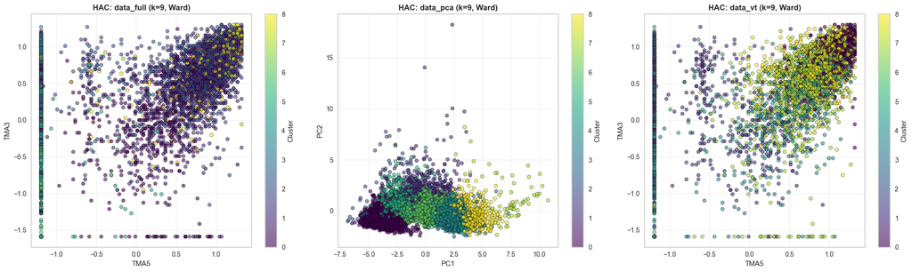

```python
fig, axes = plt.subplots(1, 3, figsize=(20, 6))

# data_full
scatter1 = axes[0].scatter(data_full_scaled[top_2_features_full[0]],
                           data_full_scaled[top_2_features_full[1]],
                           c=labels_hac_full, cmap='viridis', alpha=0.6, s=30,
                           edgecolors='black', linewidth=0.5)
axes[0].set_xlabel(top_2_features_full[0], fontsize=11)
axes[0].set_ylabel(top_2_features_full[1], fontsize=11)
axes[0].set_title(f'HAC: data_full (k={optimal_k_hac}, Ward)',
                  fontsize=12, fontweight='bold')
axes[0].grid(alpha=0.3)
plt.colorbar(scatter1, ax=axes[0], label='Cluster')

# data_pca
scatter2 = axes[1].scatter(data_pca_scaled['PC1'], data_pca_scaled['PC2'],
                           c=labels_hac_pca, cmap='viridis', alpha=0.6, s=30,
                           edgecolors='black', linewidth=0.5)
axes[1].set_xlabel('PC1', fontsize=11)
axes[1].set_ylabel('PC2', fontsize=11)
axes[1].set_title(f'HAC: data_pca (k={optimal_k_hac}, Ward)',
                  fontsize=12, fontweight='bold')
axes[1].grid(alpha=0.3)
plt.colorbar(scatter2, ax=axes[1], label='Cluster')

# data_vt
scatter3 = axes[2].scatter(data_vt_scaled[top_2_features_vt[0]],
                           data_vt_scaled[top_2_features_vt[1]],
                           c=labels_hac_vt, cmap='viridis', alpha=0.6, s=30,
                           edgecolors='black', linewidth=0.5)
axes[2].set_xlabel(top_2_features_vt[0], fontsize=11)
axes[2].set_ylabel(top_2_features_vt[1], fontsize=11)
axes[2].set_title(f'HAC: data_vt (k={optimal_k_hac}, Ward)',
                  fontsize=12, fontweight='bold')
axes[2].grid(alpha=0.3)
plt.colorbar(scatter3, ax=axes[2], label='Cluster')

plt.tight_layout()
plt.show()
```

- We see a solid pattern emerge for data_pca. data_full and data_vt can't be visually interpreted which makes sense because of the higher dimensionality. THis does however not mean they are less promising.

#### Analyze learning outcome distribution across clusters

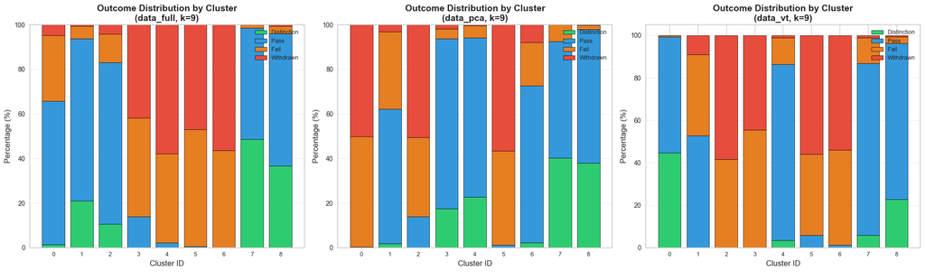

```python
### Outcome Distribution Analysis for HAC Clusters (k=9)

# Function to extract outcome from index
def extract_outcome(index_value):
    outcome_code = str(index_value)[-1]
    outcome_map = {'1': 'Withdrawn', '2': 'Fail', '3': 'Pass', '4': 'Distinction'}
    return outcome_map.get(outcome_code, 'Unknown')

# Create three separate dataframes with cluster labels (using the correct label variables)
data_with_clusters_full_hac = data_full.copy()
data_with_clusters_full_hac['cluster_hac'] = labels_hac_full
data_with_clusters_full_hac['outcome'] = data_with_clusters_full_hac.index.map(extract_outcome)

data_with_clusters_pca_hac = data_full.copy()
data_with_clusters_pca_hac['cluster_hac'] = labels_hac_pca
data_with_clusters_pca_hac['outcome'] = data_with_clusters_pca_hac.index.map(extract_outcome)

data_with_clusters_vt_hac = data_full.copy()
data_with_clusters_vt_hac['cluster_hac'] = labels_hac_vt
data_with_clusters_vt_hac['outcome'] = data_with_clusters_vt_hac.index.map(extract_outcome)

# Visualization: Stacked bar charts for all three datasets
fig, axes = plt.subplots(1, 3, figsize=(20, 6))

outcomes = ['Distinction', 'Pass', 'Fail', 'Withdrawn']
colors_outcome = {'Distinction': '#2ecc71', 'Pass': '#3498db', 'Fail': '#e67e22', 'Withdrawn': '#e74c3c'}

datasets = [
    (data_with_clusters_full_hac, 'data_full', axes[0]),
    (data_with_clusters_pca_hac, 'data_pca', axes[1]),
    (data_with_clusters_vt_hac, 'data_vt', axes[2])
]

for data_with_clusters, dataset_name, ax in datasets:
    cluster_ids = sorted(data_with_clusters['cluster_hac'].unique())
    bottoms = np.zeros(len(cluster_ids))

    for outcome in outcomes:
        percentages = []
        for cluster_id in cluster_ids:
            cluster_data = data_with_clusters[data_with_clusters['cluster_hac'] == cluster_id]
            count = (cluster_data['outcome'] == outcome).sum()
            pct = (count / len(cluster_data)) * 100
            percentages.append(pct)

        ax.bar(cluster_ids, percentages, bottom=bottoms, label=outcome,
               color=colors_outcome[outcome], edgecolor='black', linewidth=0.5)
        bottoms += percentages

    ax.set_xlabel('Cluster ID', fontsize=12)
    ax.set_ylabel('Percentage (%)', fontsize=12)
    ax.set_title(f'Outcome Distribution by Cluster\n({dataset_name}, k={optimal_k_hac})',
                 fontsize=14, fontweight='bold')
    ax.set_xticks(cluster_ids)
    ax.set_xticklabels(cluster_ids, fontsize=9)
    ax.legend(loc='upper right', fontsize=9)
    ax.grid(axis='y', alpha=0.3)

plt.tight_layout()
plt.show()
```

- For the most part (except in data_pca) the clusterings we created differentiate relatively cleanly between Distinction/Pass and Fail/Withdrawn. This indicates that different behaviour patterns that lead to these respective outcomes are not differentiable further with the features that we used.
- If we successfully reporduced (at least to a degree) Treuillier & Boyer ebery cluster should mainly contain one performance outcome. We have not achieved this (as in the other clustering approaches)
- We could now inspect single data instances to get an idea of what behaviour is represented but I found this part rather confusing with no real conclusive patterns visible. To not add more complexity to this analysis I end the data exploration here.